# Dissertation Analysis: Correct Item Collection Rate - Strategy

Jamiahus Walton

2019-06-18

# Motivation

The motivation for this analysis is to determine if there is a different in the collection rate of correct items. Previous analysis suggests that individuals in the Team condition have higher time remaining.

Specifically, at the individual level, when teams use Go Alone, model.NoInteracton indicates a significant difference between Ind_Team and Team. Specicially, Time Remaining (square root) is significantly higher in the Team feedback condition, when compared to Ind_Team feedback.

Specifically, at the individual level, wehn teams use the Go Together method, in session 4, model.All indicates a significant difference between Ind_Team and Team, and a difference between Ind and Team condition, indicating that the Team condition produced higher individual Time Remaining (Square root).

The previous analysis does not tell me how well the teams performed (e.g., were they able to collect correct items quickly?). I developed a dependent variable that will tell us how long it took for a team or individual to collect a correct item. I expect teams/individuals in the Team condition to collect correct items quicker than the other conditions.

# Correct Items Collection Rate (Sec / Item)

I generated Correct Items Collection Rate values for teams at the individual and team level.

## Team

The following is the equation for the correct item collection rate:

$$Collection.Rate_{Team} = \frac{Duration_{team}}{Total.Correct.Items.Collected_{team}}$$
Where $Duration_{team}$ is the amount of time (in seconds) the team spent in a session, $Total.Correct.Items.Collected_{team}$ is the total number of correct items (team or individual) collected during that session by the entire team. If a team collected 0 correct items, the total duration was used (e.g., the collection rate for a team that had a duration of 462 seconds and collected no correct item is 462).

**Note:** It is important to note that the lower collection rate the better the team. This is because the units are **Seconds / Items**, meaning that this variable measure the amount of time needed to collect a correct item.

## Individual

The following is the equation for the correct item collection rate:

$$Collection.Rate_{ind} = \frac{Duration_{ind}}{Total.Correct.Items.Collected_{ind}}$$

Where $Duration_{ind}$ is the amount of time (in seconds) an individual spent in a session, $Total.Correct.Items.Collected_{ind}$ is the total number of correct items (team or individual) collected during that session by the an individual. If an individual collected 0 correct items, the total duration was used (e.g., the collection rate for an individual that had a duration of 362 seconds and collected no correct item is 362).

# Q: Is there exciting variation among the *Correct Collection Rate* metric that will help me understand the influence of the feedback condition?

## Team

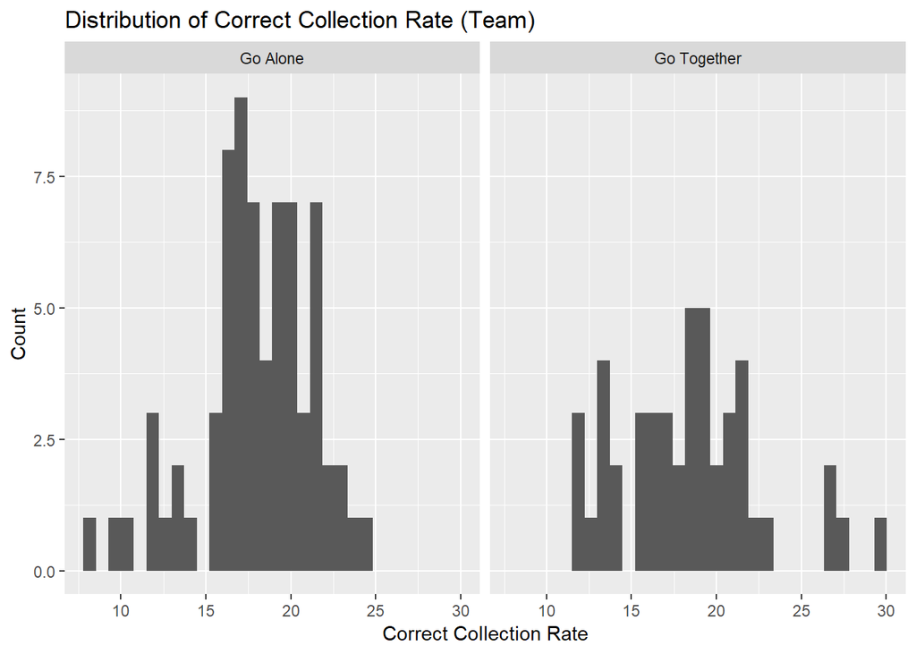

```r
y_label_team <- "Count"
x_label_team <- params$dependent_response_name_WithSpace
title_response_team <- paste("Distribution of", params$dependent_response_name_WithSpace, "(Team)")
plot_name <- paste("Histogram_", params$dependent_response_name_NoSpace, "_Team.png", sep = "")
setwd(figure_directory)

plot_data_team <- team_data %>%
  select(params$dependent_response_team,
         params$dependent_response_DominateStrategy,
         Target)

ggplot(data = plot_data_team) +
  geom_histogram(aes_string(x = params$dependent_response_team), bins = 30) +
  facet_grid( . ~ .data[[params$dependent_response_DominateStrategy]]) +
  labs(title = title_response_team, x = x_label_team, y = y_label_team) +
  ggsave(filename = plot_name)
```

There seems to be a similar distribution of correct collection rate. Both seem to be normal.

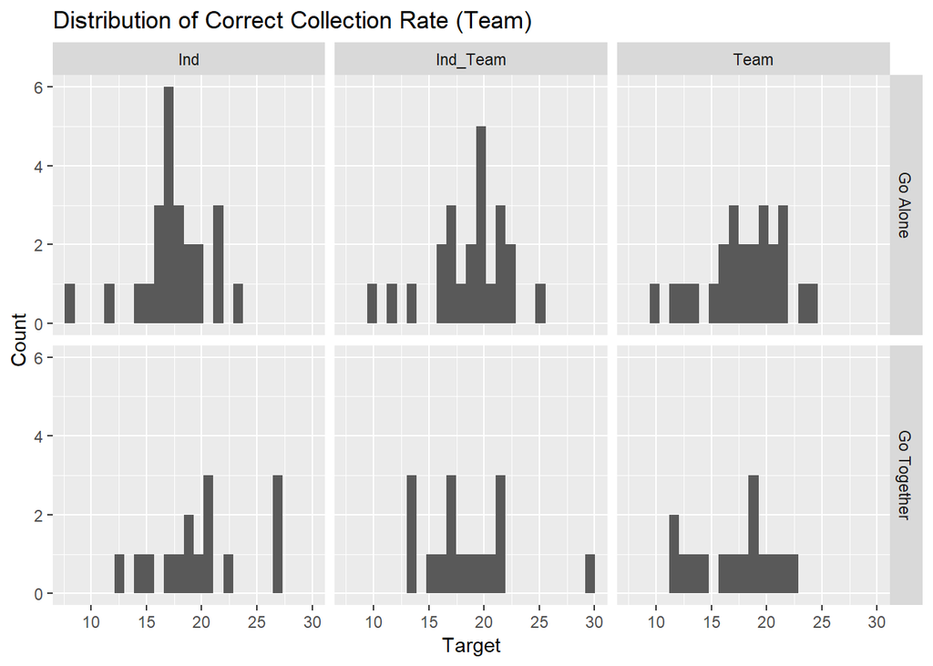

```r
y_label_team <- "Count"
x_label_team <- "Target"
title_response_team <- paste("Distribution of", params$dependent_response_name_WithSpace, "(Team)")
plot_name <- paste("Histogram_", params$dependent_response_name_NoSpace, "_ByTarget_Team.png", sep = "")
setwd(figure_directory)

plot_data_team <- team_data %>%
  select(params$dependent_response_team,
         params$dependent_response_DominateStrategy,
         Target)

ggplot(data = plot_data_team) +
  geom_histogram(aes_string(x = params$dependent_response_team), bins = 25) +
  facet_grid(.data[[params$dependent_response_DominateStrategy]] ~ Target) +
  labs(title = title_response_team, x = x_label_team, y = y_label_team) +
  ggsave(filename = plot_name)
```

```r
# Information about the N values in each condition
tableData <- team_data %>%
  group_by(Target, .data[[params$dependent_response_DominateStrategy]]) %>%
  summarise(N = length(.data[[params$dependent_response_team]]))

tableData %>%
  kable() %>%
  kable_styling()
```

| Target | Dominate.Strategy | N |
| --- | --- | --- |
| Ind | Go Alone | 24 |
| Ind | Go Together | 15 |
| Ind_Team | Go Alone | 23 |
| Ind_Team | Go Together | 16 |
| Team | Go Alone | 24 |
| Team | Go Together | 15 |

I see no obvious pattern.

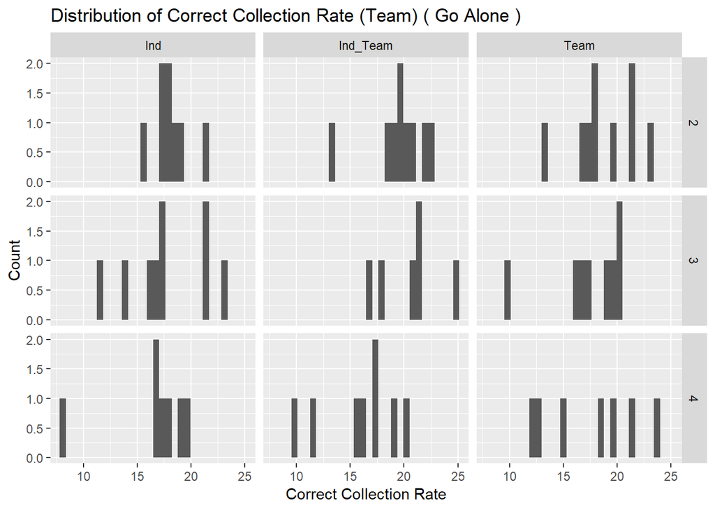

```r
y_label_team <- "Count"
x_label_team <- params$dependent_response_name_WithSpace
setwd(figure_directory)

plot_data_team <- team_data %>%
  select(params$dependent_response_team,
         params$dependent_response_DominateStrategy,
         Target,
         SessionOrder)

# Generate data by strategy
GA_plot_data_team <- plot_data_team %>%
  filter(.data[[params$dependent_response_DominateStrategy]] == params$Strategy_GA_name_WithSpace)

GT_plot_data_team <- plot_data_team %>%
  filter(.data[[params$dependent_response_DominateStrategy]] == params$Strategy_GT_name_WithSpace)

# Plot
 # GA
ggplot(data = GA_plot_data_team) +
  geom_histogram(aes_string(x = params$dependent_response_team), bins = 30) +
  labs(title = paste("Distribution of", params$dependent_response_name_WithSpace, "(Team)","(", params$Strategy_GA_name_WithSpace ,")" ), x = x_label_team, y = y_label_team) +
  facet_grid( SessionOrder ~ Target) +
  ggsave(filename = paste("Histogram_", params$dependent_response_name_NoSpace, "_ByTarget_BySessionOrder_", params$Strategy_GA_name_NoSpace, "_Team.png", sep = ""))
```

```r
    # Information about the N values in each condition
GA_tableData <- GA_plot_data_team %>%
  select(params$dependent_response_team, Target, SessionOrder) %>%
  group_by(Target, SessionOrder) %>%
  summarise(N = length(.data[[params$dependent_response_team]]))

GA_tableData %>%
  kable(caption = paste("Data for ", params$Strategy_GA_name_WithSpace)) %>%
  kable_styling()
```

Data for Go Alone

| Target | SessionOrder | N |
| --- | --- | --- |
| Ind | 2 | 8 |
| Ind | 3 | 9 |
| Ind | 4 | 7 |
| Ind_Team | 2 | 9 |
| Ind_Team | 3 | 6 |
| Ind_Team | 4 | 8 |
| Team | 2 | 9 |
| Team | 3 | 8 |
| Team | 4 | 7 |

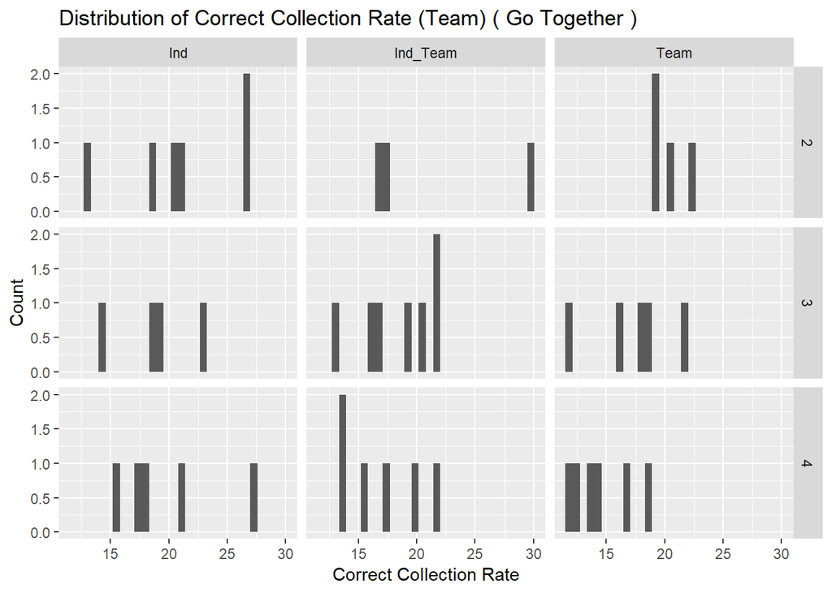

```r
 # GT
ggplot(data = GT_plot_data_team) +
  geom_histogram(aes_string(x = params$dependent_response_team), bins = 30) +
  labs(title = paste("Distribution of", params$dependent_response_name_WithSpace, "(Team)","(", params$Strategy_GT_name_WithSpace ,")" ), x = x_label_team, y = y_label_team) +
  facet_grid( SessionOrder ~ Target) +
  ggsave(filename = paste("Histogram_", params$dependent_response_name_NoSpace, "_ByTarget_BySessionOrder_", params$Strategy_GT_name_NoSpace, "_Team.png", sep = ""))
```

```r
    # Information about the N values in each condition
GT_tableData <- GT_plot_data_team %>%
  select(params$dependent_response_team, Target, SessionOrder) %>%
  group_by(Target, SessionOrder) %>%
  summarise(N = length(.data[[params$dependent_response_team]]))

GT_tableData %>%
  kable(caption = paste("Data for ", params$Strategy_GT_name_WithSpace)) %>%
  kable_styling()
```

Data for Go Together

| Target | SessionOrder | N |
| --- | --- | --- |
| Ind | 2 | 6 |
| Ind | 3 | 4 |
| Ind | 4 | 5 |
| Ind_Team | 2 | 3 |
| Ind_Team | 3 | 7 |
| Ind_Team | 4 | 6 |
| Team | 2 | 4 |
| Team | 3 | 5 |
| Team | 4 | 6 |

No obvious patterns jump out at me.

Go Alone: It does look like the distributions flatten over time in Ind_Team and Team condition

## Individual

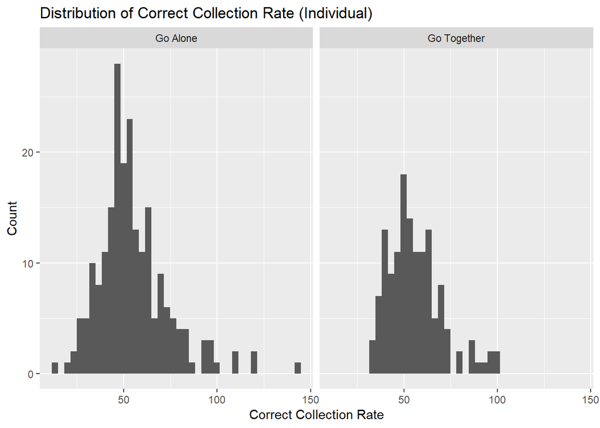

```r
y_label_ind <- "Count"
x_label_ind <- params$dependent_response_name_WithSpace
title_response_ind <- paste("Distribution of", params$dependent_response_name_WithSpace, "(Individual)")
plot_name <- paste("Histogram_", params$dependent_response_name_NoSpace, "_Ind.png", sep = "")
setwd(figure_directory)

plot_data_ind <- ind_data %>%
  select(params$dependent_response_ind, params$dependent_response_DominateStrategy, Target)

ggplot(data = plot_data_ind) +
  geom_histogram(aes_string(x = params$dependent_response_ind), bins = 40) +
  facet_grid(. ~ .data[[params$dependent_response_DominateStrategy]]) +
  labs(title = title_response_ind, x = x_label_ind, y = y_label_ind) +
  ggsave(filename = plot_name)
```

There seems to be a normal distribution when grouping the data by Strategy.

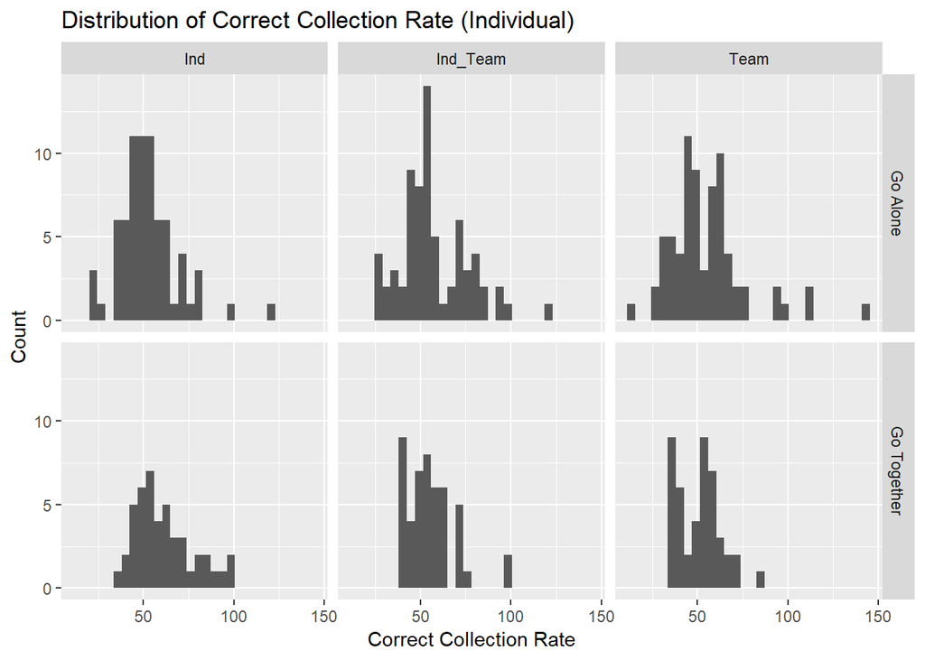

```r
y_label_ind <- "Count"
x_label_ind <- params$dependent_response_name_WithSpace
title_response_ind <- paste("Distribution of", params$dependent_response_name_WithSpace, "(Individual)")
plot_name <- paste("Histogram_", params$dependent_response_name_NoSpace, "_ByTarget_Ind.png", sep = "")
setwd(figure_directory)

plot_data_ind <- ind_data %>%
  select(params$dependent_response_ind, params$dependent_response_DominateStrategy, Target)

ggplot(data = plot_data_ind) +
  geom_histogram(aes_string(x = params$dependent_response_ind), bins = 30) +
  facet_grid(.data[[params$dependent_response_DominateStrategy]] ~ Target) +
  labs(title = title_response_ind, x = x_label_ind, y = y_label_ind) +
  ggsave(filename = plot_name)
```

```r
# Information about the N values in each condition
tableData <- ind_data %>%
  group_by(Target, .data[[params$dependent_response_DominateStrategy]]) %>%
  summarise(N = length(.data[[params$dependent_response_ind]]))

tableData %>%
  kable() %>%
  kable_styling()
```

| Target | Dominate.Strategy | N |
| --- | --- | --- |
| Ind | Go Alone | 72 |
| Ind | Go Together | 45 |
| Ind_Team | Go Alone | 69 |
| Ind_Team | Go Together | 48 |
| Team | Go Alone | 72 |
| Team | Go Together | 45 |

No obvious pattern jumps out at me. There does seem to be a wide varience in the Go Together-Individual condition.

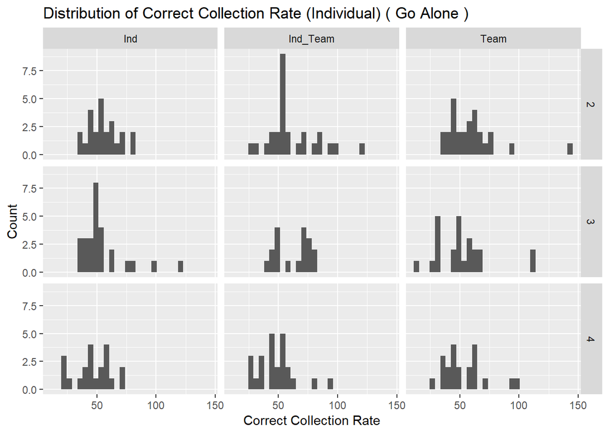

```r
y_label_ind <- "Count"
x_label_ind <- params$dependent_response_name_WithSpace
setwd(figure_directory)

plot_data_ind <- ind_data %>%
  select(params$dependent_response_ind,
         params$dependent_response_DominateStrategy,
         Target,
         SessionOrder)

# Generate data by strategy
GA_plot_data_ind <- plot_data_ind %>%
  filter(.data[[params$dependent_response_DominateStrategy]] == params$Strategy_GA_name_WithSpace)

GT_plot_data_ind <- plot_data_ind %>%
  filter(.data[[params$dependent_response_DominateStrategy]] == params$Strategy_GT_name_WithSpace)

# plot
  # GA
ggplot(data = GA_plot_data_ind) +
  geom_histogram(aes_string(x = params$dependent_response_ind), bins = 30) +
  facet_grid(SessionOrder ~ Target) +
  labs(title = paste("Distribution of", params$dependent_response_name_WithSpace, "(Individual)","(", params$Strategy_GA_name_WithSpace ,")" ), x = x_label_ind, y = y_label_ind) +
  ggsave(filename = paste("Histogram_", params$dependent_response_name_NoSpace, "_ByTarget_BySessionOrder_", params$Strategy_GA_name_NoSpace, "_Ind.png", sep = ""))
```

```r
    # Information about the N values in each condition
GA_tableData <- GA_plot_data_ind %>%
  select(params$dependent_response_ind, Target, SessionOrder) %>%
  group_by(Target, SessionOrder) %>%
  summarise(N = length(.data[[params$dependent_response_ind]]))

GA_tableData %>%
  kable(caption =  paste("Data for ", params$Strategy_GA_name_WithSpace)) %>%
  kable_styling()
```

Data for Go Alone

| Target | SessionOrder | N |
| --- | --- | --- |
| Ind | 2 | 24 |
| Ind | 3 | 27 |
| Ind | 4 | 21 |
| Ind_Team | 2 | 27 |
| Ind_Team | 3 | 18 |
| Ind_Team | 4 | 24 |
| Team | 2 | 27 |
| Team | 3 | 24 |
| Team | 4 | 21 |

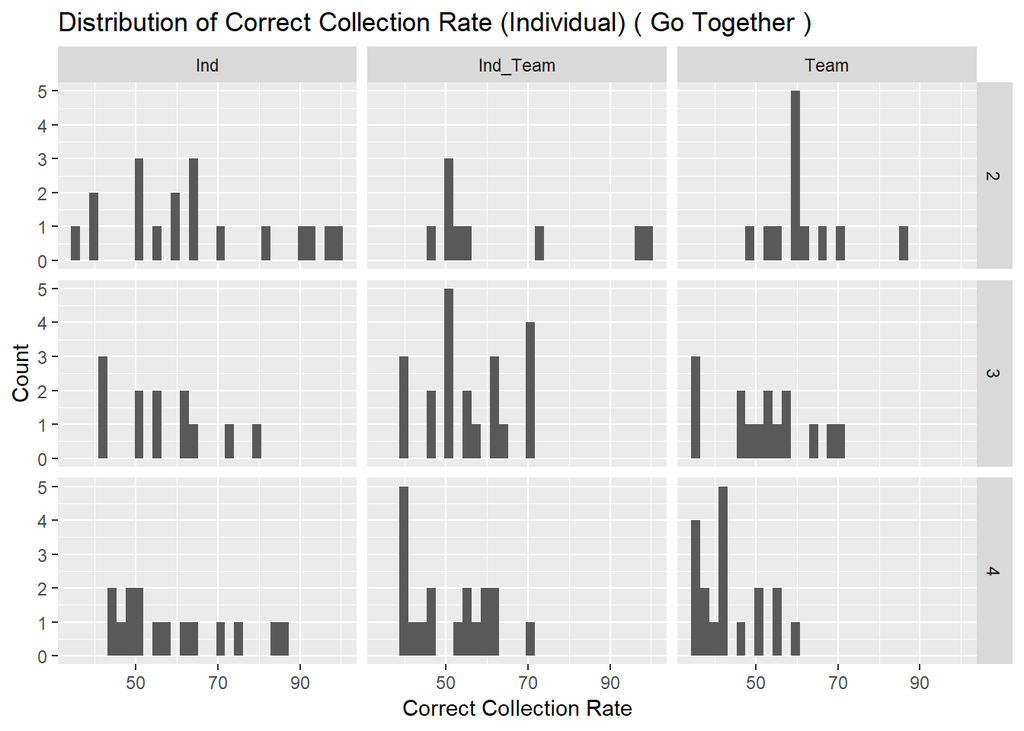

```r
  # GT
ggplot(data = GT_plot_data_ind) +
  geom_histogram(aes_string(x = params$dependent_response_ind), bins = 30) +
  facet_grid(SessionOrder ~ Target) +
  labs(title = paste("Distribution of", params$dependent_response_name_WithSpace, "(Individual)","(", params$Strategy_GT_name_WithSpace ,")" ), x = x_label_ind, y = y_label_ind) +
  ggsave(filename = paste("Histogram_", params$dependent_response_name_NoSpace, "_ByTarget_BySessionOrder_", params$Strategy_GT_name_NoSpace, "_Ind.png", sep = ""))
```

```r
# Information about the N values in each condition
GT_tableData <- GT_plot_data_ind %>%
  select(params$dependent_response_ind, Target, SessionOrder) %>%
  group_by(Target, SessionOrder) %>%
  summarise(N = length(.data[[params$dependent_response_ind]]))

GT_tableData %>%
  kable(caption = paste("Data for ", params$Strategy_GT_name_WithSpace)) %>%
  kable_styling()
```

Data for Go Together

| Target | SessionOrder | N |
| --- | --- | --- |
| Ind | 2 | 18 |
| Ind | 3 | 12 |
| Ind | 4 | 15 |
| Ind_Team | 2 | 9 |
| Ind_Team | 3 | 21 |
| Ind_Team | 4 | 18 |
| Team | 2 | 12 |
| Team | 3 | 15 |
| Team | 4 | 18 |

No obvious pattern. It is intersting to note that in Go Together, the Team conditions seems to noticably shift to the left. Indicating those teams needed less time to collect correct items.

## Summary

Overall, there were no obvvious patterns worth noting.

# Q: Is there an interaction between the Target and Session Order for the *Correct Collection Rate* that is statistically significant?

I am interested in determining if a linear mixed effect model should include the interaction effect between the Target and Session Order variable.

A note on the effect size ($R^2$). This method generates two types of ($R^2$) values called marginal ($R_{m}^2$) and conditional ($R_{c}^2$) effect size. The $R_{m}^2$ calculates how much of the variance is described by the fixed effect variables (feedback condition and session order) while the $R_{c}^2$ calculates how much of the variance is described by both the fixed and random effect variables.

## Full Models Used for Team and Individual

The next two sections below describe the full model for team and individual level analysis. Five models were fitted and then compared. One model was the null model, one model was the full model, and the last three are a subset of the full model.

### Team Full Model

$$y_{ijt} = \mu + \alpha_{i} + \beta_{j} + \alpha_{i} \beta_{j} + \gamma_{t} + \epsilon_{ijt}$$

### Individual Team Full Model

$$y_{ijtp} = \mu + \alpha_{i} + \beta_{j} + \alpha_{i} \beta_{j} + \gamma_{t} + \theta_{p} + \epsilon_{ijtp}$$

## Team

### GA

```r
# Data to fit
data_modified_team <- team_data %>%
  select(TeamScore,
         params$dependent_response_team,
         params$dependent_response_DominateStrategy,
         Target,
         SessionOrder,
         Team)

# Generate models with variable response
GA_data_focus_team <- data_modified_team %>%
  filter(.data[[params$dependent_response_DominateStrategy]] == params$Strategy_GA_name_WithSpace)

model.null <- model_data_Target_Session(df = GA_data_focus_team, dependent =  params$dependent_response_team, model.type =  "null", is.team = TRUE, is.robust =FALSE)
model.All <- model_data_Target_Session(df = GA_data_focus_team, dependent =  params$dependent_response_team, model.type =  "All", is.team = TRUE, is.robust = FALSE)
model.NoInteraction <- model_data_Target_Session(df = GA_data_focus_team, dependent =  params$dependent_response_team, model.type =  "NoInteraction", is.team = TRUE, is.robust = FALSE)
model.NoInteraction.NoTarget <- model_data_Target_Session(df = GA_data_focus_team, dependent =  params$dependent_response_team, model.type =  "NoInteraction_NoTarget", is.team = TRUE, is.robust = FALSE)
model.NoInteraction.NoSession <- model_data_Target_Session(df = GA_data_focus_team, dependent =  params$dependent_response_team, model.type =  "NoInteraction_NoSession", is.team = TRUE, is.robust = FALSE)

# There is an option to compare all the models with the anova(). However, the function does not compare all models to model.null
anova(model.null,
      model.All) %>%
  kable(caption = "ANOVA: Null and All") %>%
  kable_styling()
```

```
## refitting model(s) with ML (instead of REML)
```

ANOVA: Null and All

|  | Df | AIC | BIC | logLik | deviance | Chisq | Chi Df | Pr(>Chisq) |
| --- | --- | --- | --- | --- | --- | --- | --- | --- |
| model.null | 3 | 352.0453 | 358.8333 | -173.0226 | 346.0453 | NA | NA | NA |
| model.All | 11 | 339.3647 | 364.2542 | -158.6823 | 317.3647 | 28.68061 | 8 | 0.0003607 |

```r
anova(model.null,
      model.NoInteraction) %>%
  kable(caption = "ANOVA: Null and No.Interaction") %>%
  kable_styling()
```

```
## refitting model(s) with ML (instead of REML)
```

ANOVA: Null and No.Interaction

|  | Df | AIC | BIC | logLik | deviance | Chisq | Chi Df | Pr(>Chisq) |
| --- | --- | --- | --- | --- | --- | --- | --- | --- |
| model.null | 3 | 352.0453 | 358.8333 | -173.0226 | 346.0453 | NA | NA | NA |
| model.NoInteraction | 7 | 337.7757 | 353.6145 | -161.8879 | 323.7757 | 22.26957 | 4 | 0.0001771 |

```r
anova(model.null,
      model.NoInteraction.NoTarget) %>%
  kable(caption = "ANOVA: Null and No.Interaction.No.Target") %>%
  kable_styling()
```

```
## refitting model(s) with ML (instead of REML)
```

ANOVA: Null and No.Interaction.No.Target

|  | Df | AIC | BIC | logLik | deviance | Chisq | Chi Df | Pr(>Chisq) |
| --- | --- | --- | --- | --- | --- | --- | --- | --- |
| model.null | 3 | 352.0453 | 358.8333 | -173.0226 | 346.0453 | NA | NA | NA |
| model.NoInteraction.NoTarget | 5 | 338.2033 | 349.5167 | -164.1016 | 328.2033 | 17.84201 | 2 | 0.0001336 |

```r
anova(model.null,
      model.NoInteraction.NoSession) %>%
  kable(caption = "ANOVA: Null and No.Interaction.No.Session") %>%
  kable_styling()
```

```
## refitting model(s) with ML (instead of REML)
```

ANOVA: Null and No.Interaction.No.Session

|  | Df | AIC | BIC | logLik | deviance | Chisq | Chi Df | Pr(>Chisq) |
| --- | --- | --- | --- | --- | --- | --- | --- | --- |
| model.null | 3 | 352.0453 | 358.8333 | -173.0226 | 346.0453 | NA | NA | NA |
| model.NoInteraction.NoSession | 5 | 353.1125 | 364.4259 | -171.5563 | 343.1125 | 2.93276 | 2 | 0.2307594 |

The following models were significantly different from the null model: model.All, model.NoInteraction, model.NoInteraction.NoTarget.

model.All: Session Order, Target, and the interaction are included in this model.

model.NoInteraction: Session order and target are the fixed effects in this model.

model.NoInteraction.NoTarget: Session order is the only fixed effect in this model.

```r
# Data to fit
data_modified_team <- team_data %>%
  select(TeamScore,
         params$dependent_response_team,
         params$dependent_response_DominateStrategy,
         Target,
         SessionOrder,
         Team)

# Generate models with variable response
GA_data_focus_team <- data_modified_team %>%
  filter(.data[[params$dependent_response_DominateStrategy]] == params$Strategy_GA_name_WithSpace)

model.All <- model_data_Target_Session(df = GA_data_focus_team, dependent =  params$dependent_response_team, model.type =  "All", is.team = TRUE, is.robust = FALSE)
model.NoInteraction <- model_data_Target_Session(df = GA_data_focus_team, dependent =  params$dependent_response_team, model.type =  "NoInteraction", is.team = TRUE, is.robust = FALSE)
model.NoInteraction.NoTarget <- model_data_Target_Session(df = GA_data_focus_team, dependent =  params$dependent_response_team, model.type =  "NoInteraction_NoTarget", is.team = TRUE, is.robust = FALSE)

# Compare all of the models
anova(model.All,
      model.NoInteraction) %>%
  kable(caption = "ANOVA: model.All and model.NoInteraction") %>%
  kable_styling()
```

```
## refitting model(s) with ML (instead of REML)
```

ANOVA: model.All and model.NoInteraction

|  | Df | AIC | BIC | logLik | deviance | Chisq | Chi Df | Pr(>Chisq) |
| --- | --- | --- | --- | --- | --- | --- | --- | --- |
| model.NoInteraction | 7 | 337.7757 | 353.6145 | -161.8879 | 323.7757 | NA | NA | NA |
| model.All | 11 | 339.3647 | 364.2542 | -158.6823 | 317.3647 | 6.411042 | 4 | 0.1704825 |

```r
anova(model.All,
      model.NoInteraction.NoTarget) %>%
  kable(caption = "ANOVA: model.All and model.NoInteraction.NoTarget") %>%
  kable_styling()
```

```
## refitting model(s) with ML (instead of REML)
```

ANOVA: model.All and model.NoInteraction.NoTarget

|  | Df | AIC | BIC | logLik | deviance | Chisq | Chi Df | Pr(>Chisq) |
| --- | --- | --- | --- | --- | --- | --- | --- | --- |
| model.NoInteraction.NoTarget | 5 | 338.2033 | 349.5167 | -164.1016 | 328.2033 | NA | NA | NA |
| model.All | 11 | 339.3647 | 364.2542 | -158.6823 | 317.3647 | 10.8386 | 6 | 0.0934948 |

```r
anova(model.NoInteraction,
      model.NoInteraction.NoTarget) %>%
  kable(caption = "ANOVA: model.NoInteraction and model.NoInteraction.NoTarget") %>%
  kable_styling()
```

```
## refitting model(s) with ML (instead of REML)
```

ANOVA: model.NoInteraction and model.NoInteraction.NoTarget

|  | Df | AIC | BIC | logLik | deviance | Chisq | Chi Df | Pr(>Chisq) |
| --- | --- | --- | --- | --- | --- | --- | --- | --- |
| model.NoInteraction.NoTarget | 5 | 338.2033 | 349.5167 | -164.1016 | 328.2033 | NA | NA | NA |
| model.NoInteraction | 7 | 337.7757 | 353.6145 | -161.8879 | 323.7757 | 4.427554 | 2 | 0.1092871 |

model.All is not significantly different from the other models, suggesting that the interaction effect can be excluded from the model. model.NoInteraction us not significantly different from model.NoInteraction.NoTarget. However, AIC and BIC values are similar. I will look at the r squared values to compare the effect sizes.

```r
# Data to fit
data_modified_team <- team_data %>%
  select(TeamScore,
         params$dependent_response_team,
         params$dependent_response_DominateStrategy,
         Target,
         SessionOrder,
         Team)

# Generate models with variable response
GA_data_focus_team <- data_modified_team %>%
  filter(.data[[params$dependent_response_DominateStrategy]] == params$Strategy_GA_name_WithSpace)

model.NoInteraction <- model_data_Target_Session(df = GA_data_focus_team, dependent =  params$dependent_response_team, model.type =  "NoInteraction", is.team = TRUE, is.robust = FALSE)
model.NoInteraction.NoTarget <- model_data_Target_Session(df = GA_data_focus_team, dependent =  params$dependent_response_team, model.type =  "NoInteraction_NoTarget", is.team = TRUE, is.robust = FALSE)

# Effect size (R^2)

r.squaredGLMM(model.NoInteraction.NoTarget) %>%
  kable(caption = "Table: Effect size for *No Interaction and No Target*") %>%
   kable_styling(full_width = F)
```

Table: Effect size for *No Interaction and No Target*

| R2m | R2c |
| --- | --- |
| 0.0841212 | 0.7353612 |

```r
r.squaredGLMM(model.NoInteraction) %>%
  kable(caption = "Table: Effect size for *No Interaction*") %>%
   kable_styling(full_width = F)
```

Table: Effect size for *No Interaction*

| R2m | R2c |
| --- | --- |
| 0.098867 | 0.7450975 |

Each model explains a similar amount of the varience. I wll analyze **model.NoInteraction.NoTarget** and **model.NoInteraction**.

### GT

```r
# Data to fit
data_modified_team <- team_data %>%
  select(TeamScore,
         params$dependent_response_team,
         params$dependent_response_DominateStrategy,
         Target,
         SessionOrder,
         Team)

# Generate models with variable response
GT_data_focus_team <- data_modified_team %>%
  filter(.data[[params$dependent_response_DominateStrategy]] == params$Strategy_GT_name_WithSpace)

model.null <- model_data_Target_Session(df = GT_data_focus_team, dependent =  params$dependent_response_team, model.type =  "null", is.team = TRUE, is.robust =FALSE)
model.All <- model_data_Target_Session(df = GT_data_focus_team, dependent =  params$dependent_response_team, model.type =  "All", is.team = TRUE, is.robust = FALSE)
model.NoInteraction <- model_data_Target_Session(df = GT_data_focus_team, dependent =  params$dependent_response_team, model.type =  "NoInteraction", is.team = TRUE, is.robust = FALSE)
model.NoInteraction.NoTarget <- model_data_Target_Session(df = GT_data_focus_team, dependent =  params$dependent_response_team, model.type =  "NoInteraction_NoTarget", is.team = TRUE, is.robust = FALSE)
model.NoInteraction.NoSession <- model_data_Target_Session(df = GT_data_focus_team, dependent =  params$dependent_response_team, model.type =  "NoInteraction_NoSession", is.team = TRUE, is.robust = FALSE)

# There is an option to compare all the models with the anova(). However, the function does not compare all models to model.null
anova(model.null,
      model.All) %>%
  kable(caption = "ANOVA: Null and All") %>%
  kable_styling()
```

```
## refitting model(s) with ML (instead of REML)
```

ANOVA: Null and All

|  | Df | AIC | BIC | logLik | deviance | Chisq | Chi Df | Pr(>Chisq) |
| --- | --- | --- | --- | --- | --- | --- | --- | --- |
| model.null | 3 | 260.3493 | 265.8352 | -127.1746 | 254.3493 | NA | NA | NA |
| model.All | 11 | 248.2703 | 268.3853 | -113.1351 | 226.2703 | 28.07898 | 8 | 0.0004595 |

```r
anova(model.null,
      model.NoInteraction) %>%
  kable(caption = "ANOVA: Null and No.Interaction") %>%
  kable_styling()
```

```
## refitting model(s) with ML (instead of REML)
```

ANOVA: Null and No.Interaction

|  | Df | AIC | BIC | logLik | deviance | Chisq | Chi Df | Pr(>Chisq) |
| --- | --- | --- | --- | --- | --- | --- | --- | --- |
| model.null | 3 | 260.3493 | 265.8352 | -127.1746 | 254.3493 | NA | NA | NA |
| model.NoInteraction | 7 | 240.6076 | 253.4081 | -113.3038 | 226.6076 | 27.74162 | 4 | 1.41e-05 |

```r
anova(model.null,
      model.NoInteraction.NoTarget) %>%
  kable(caption = "ANOVA: Null and No.Interaction.No.Target") %>%
  kable_styling()
```

```
## refitting model(s) with ML (instead of REML)
```

ANOVA: Null and No.Interaction.No.Target

|  | Df | AIC | BIC | logLik | deviance | Chisq | Chi Df | Pr(>Chisq) |
| --- | --- | --- | --- | --- | --- | --- | --- | --- |
| model.null | 3 | 260.3493 | 265.8352 | -127.1746 | 254.3493 | NA | NA | NA |
| model.NoInteraction.NoTarget | 5 | 242.2344 | 251.3776 | -116.1172 | 232.2344 | 22.11488 | 2 | 1.58e-05 |

```r
anova(model.null,
      model.NoInteraction.NoSession) %>%
  kable(caption = "ANOVA: Null and No.Interaction.No.Session") %>%
  kable_styling()
```

```
## refitting model(s) with ML (instead of REML)
```

ANOVA: Null and No.Interaction.No.Session

|  | Df | AIC | BIC | logLik | deviance | Chisq | Chi Df | Pr(>Chisq) |
| --- | --- | --- | --- | --- | --- | --- | --- | --- |
| model.null | 3 | 260.3493 | 265.8352 | -127.1746 | 254.3493 | NA | NA | NA |
| model.NoInteraction.NoSession | 5 | 258.8513 | 267.9945 | -124.4256 | 248.8513 | 5.497988 | 2 | 0.0639922 |

The following models were significantly different from the null model: model.All, model.NoInteraction, model.NoInteraction.NoTarget.

model.All: Session Order, Target, and the interaction are included in this model.

model.NoInteraction: Session order and target are the fixed effects in this model.

model.NoInteraction.NoTarget: Session order is the only fixed effect in this model.

```r
# Data to fit
data_modified_team <- team_data %>%
  select(TeamScore,
         params$dependent_response_team,
         params$dependent_response_DominateStrategy,
         Target,
         SessionOrder,
         Team)

# Generate models with variable response
GT_data_focus_team <- data_modified_team %>%
  filter(.data[[params$dependent_response_DominateStrategy]] == params$Strategy_GT_name_WithSpace)

model.All <- model_data_Target_Session(df = GT_data_focus_team, dependent =  params$dependent_response_team, model.type =  "All", is.team = TRUE, is.robust = FALSE)
model.NoInteraction <- model_data_Target_Session(df = GT_data_focus_team, dependent =  params$dependent_response_team, model.type =  "NoInteraction", is.team = TRUE, is.robust = FALSE)
model.NoInteraction.NoTarget <- model_data_Target_Session(df = GT_data_focus_team, dependent =  params$dependent_response_team, model.type =  "NoInteraction_NoTarget", is.team = TRUE, is.robust = FALSE)

# Compare all of the models
anova(model.All,
      model.NoInteraction) %>%
  kable(caption = "ANOVA: model.All and model.NoInteraction") %>%
  kable_styling()
```

```
## refitting model(s) with ML (instead of REML)
```

ANOVA: model.All and model.NoInteraction

|  | Df | AIC | BIC | logLik | deviance | Chisq | Chi Df | Pr(>Chisq) |
| --- | --- | --- | --- | --- | --- | --- | --- | --- |
| model.NoInteraction | 7 | 240.6076 | 253.4081 | -113.3038 | 226.6076 | NA | NA | NA |
| model.All | 11 | 248.2703 | 268.3853 | -113.1351 | 226.2703 | 0.3373559 | 4 | 0.9872768 |

```r
anova(model.All,
      model.NoInteraction.NoTarget) %>%
  kable(caption = "ANOVA: model.All and model.NoInteraction.NoTarget") %>%
  kable_styling()
```

```
## refitting model(s) with ML (instead of REML)
```

ANOVA: model.All and model.NoInteraction.NoTarget

|  | Df | AIC | BIC | logLik | deviance | Chisq | Chi Df | Pr(>Chisq) |
| --- | --- | --- | --- | --- | --- | --- | --- | --- |
| model.NoInteraction.NoTarget | 5 | 242.2344 | 251.3776 | -116.1172 | 232.2344 | NA | NA | NA |
| model.All | 11 | 248.2703 | 268.3853 | -113.1351 | 226.2703 | 5.964096 | 6 | 0.4272241 |

```r
anova(model.NoInteraction,
      model.NoInteraction.NoTarget) %>%
  kable(caption = "ANOVA: model.NoInteraction and model.NoInteraction.NoTarget") %>%
  kable_styling()
```

```
## refitting model(s) with ML (instead of REML)
```

ANOVA: model.NoInteraction and model.NoInteraction.NoTarget

|  | Df | AIC | BIC | logLik | deviance | Chisq | Chi Df | Pr(>Chisq) |
| --- | --- | --- | --- | --- | --- | --- | --- | --- |
| model.NoInteraction.NoTarget | 5 | 242.2344 | 251.3776 | -116.1172 | 232.2344 | NA | NA | NA |
| model.NoInteraction | 7 | 240.6076 | 253.4081 | -113.3038 | 226.6076 | 5.62674 | 2 | 0.0600024 |

model.All is not significantly different from the other models, suggesting that the interaction effect can be excluded from the model. model.NoInteraction is not significantly different from model.NoInteraction.NoTarget. It is important to note that the difference between the models is margnially significant. However, AIC and BIC values are similar. I will look at the r squared values to compare the effect sizes.

```r
# Data to fit
data_modified_team <- team_data %>%
  select(TeamScore,
         params$dependent_response_team,
         params$dependent_response_DominateStrategy,
         Target,
         SessionOrder,
         Team)

# Generate models with variable response
GT_data_focus_team <- data_modified_team %>%
  filter(.data[[params$dependent_response_DominateStrategy]] == params$Strategy_GT_name_WithSpace)

model.NoInteraction <- model_data_Target_Session(df = GT_data_focus_team, dependent =  params$dependent_response_team, model.type =  "NoInteraction", is.team = TRUE, is.robust = FALSE)
model.NoInteraction.NoTarget <- model_data_Target_Session(df = GT_data_focus_team, dependent =  params$dependent_response_team, model.type =  "NoInteraction_NoTarget", is.team = TRUE, is.robust = FALSE)

# Effect size (R^2)

r.squaredGLMM(model.NoInteraction.NoTarget) %>%
  kable(caption = "Table: Effect size for *No Interaction and No Target*") %>%
   kable_styling(full_width = F)
```

Table: Effect size for *No Interaction and No Target*

| R2m | R2c |
| --- | --- |
| 0.1733121 | 0.7977494 |

```r
r.squaredGLMM(model.NoInteraction) %>%
  kable(caption = "Table: Effect size for *No Interaction*") %>%
   kable_styling(full_width = F)
```

Table: Effect size for *No Interaction*

| R2m | R2c |
| --- | --- |
| 0.1967751 | 0.8041467 |

Each model explains a similar amount of the varience. I wll analyze **model.NoInteraction.NoTarget** and **model.NoInteraction**.

## Individual

### GA

```r
# Data to model
data_modified_ind <- ind_data %>%
  select(params$dependent_response_ind,
         params$dependent_response_DominateStrategy,
         Target,
         SessionOrder,
         Team,
         Player_ID)

# Generate models with variable response
GA_data_focus_ind <- data_modified_ind %>%
  filter(.data[[params$dependent_response_DominateStrategy]] == params$Strategy_GA_name_WithSpace)

model.null <- model_data_Target_Session(df = GA_data_focus_ind, dependent =  params$dependent_response_ind, model.type =  "null", is.team = FALSE, is.robust = FALSE)
model.All <- model_data_Target_Session(df = GA_data_focus_ind, dependent =  params$dependent_response_ind, model.type =  "All", is.team = FALSE, is.robust = FALSE)
model.NoInteraction <- model_data_Target_Session(df = GA_data_focus_ind, dependent =  params$dependent_response_ind, model.type =  "NoInteraction", is.team = FALSE, is.robust = FALSE)
model.NoInteraction.NoTarget <- model_data_Target_Session(df = GA_data_focus_ind, dependent =  params$dependent_response_ind, model.type =  "NoInteraction_NoTarget", is.team = FALSE, is.robust = FALSE)
model.NoInteraction.NoSession <- model_data_Target_Session(df = GA_data_focus_ind, dependent =  params$dependent_response_ind, model.type =  "NoInteraction_NoSession", is.team = FALSE, is.robust = FALSE)
# There is an option to compare all the models with the anova(). However, the function does not compare all models to model.null
anova(model.null,
      model.All) %>%
  kable(caption = "ANOVA: model.null and model.All") %>%
  kable_styling()
```

```
## refitting model(s) with ML (instead of REML)
```

ANOVA: model.null and model.All

|  | Df | AIC | BIC | logLik | deviance | Chisq | Chi Df | Pr(>Chisq) |
| --- | --- | --- | --- | --- | --- | --- | --- | --- |
| model.null | 4 | 1804.154 | 1817.599 | -898.0770 | 1796.154 | NA | NA | NA |
| model.All | 12 | 1792.432 | 1832.768 | -884.2161 | 1768.432 | 27.72174 | 8 | 0.0005302 |

```r
anova(model.null,
      model.NoInteraction) %>%
  kable(caption = "ANOVA: model.null and model.NoInteraction") %>%
  kable_styling()
```

```
## refitting model(s) with ML (instead of REML)
```

ANOVA: model.null and model.NoInteraction

|  | Df | AIC | BIC | logLik | deviance | Chisq | Chi Df | Pr(>Chisq) |
| --- | --- | --- | --- | --- | --- | --- | --- | --- |
| model.null | 4 | 1804.154 | 1817.599 | -898.0770 | 1796.154 | NA | NA | NA |
| model.NoInteraction | 8 | 1787.267 | 1814.157 | -885.6333 | 1771.267 | 24.88741 | 4 | 5.3e-05 |

```r
anova(model.null,
      model.NoInteraction.NoTarget) %>%
  kable(caption = "ANOVA: model.null and model.NoInteraction.NoTarget") %>%
  kable_styling()
```

```
## refitting model(s) with ML (instead of REML)
```

ANOVA: model.null and model.NoInteraction.NoTarget

|  | Df | AIC | BIC | logLik | deviance | Chisq | Chi Df | Pr(>Chisq) |
| --- | --- | --- | --- | --- | --- | --- | --- | --- |
| model.null | 4 | 1804.154 | 1817.599 | -898.0770 | 1796.154 | NA | NA | NA |
| model.NoInteraction.NoTarget | 6 | 1787.813 | 1807.981 | -887.9067 | 1775.813 | 20.34061 | 2 | 3.83e-05 |

```r
anova(model.null,
      model.NoInteraction.NoSession) %>%
  kable(caption = "ANOVA: model.null and model.NoInteraction.NoSession") %>%
  kable_styling()
```

```
## refitting model(s) with ML (instead of REML)
```

ANOVA: model.null and model.NoInteraction.NoSession

|  | Df | AIC | BIC | logLik | deviance | Chisq | Chi Df | Pr(>Chisq) |
| --- | --- | --- | --- | --- | --- | --- | --- | --- |
| model.null | 4 | 1804.154 | 1817.599 | -898.0770 | 1796.154 | NA | NA | NA |
| model.NoInteraction.NoSession | 6 | 1804.115 | 1824.283 | -896.0577 | 1792.115 | 4.038498 | 2 | 0.1327551 |

The following models were significantly different from the null model: model.All, model.NoInteraction, model.NoInteraction.NoTarget.

model.All: Session Order, Target, and the interaction are included in this model.

model.NoInteraction: Session order and target are the fixed effects in this model.

model.NoInteraction.NoTarget: Session order is the only fixed effect in this model.

```r
# Data to model
data_modified_ind <- ind_data %>%
  select(params$dependent_response_ind,
         params$dependent_response_DominateStrategy,
         Target,
         SessionOrder,
         Team,
         Player_ID)

# Generate models with variable response
GA_data_focus_ind <- data_modified_ind %>%
  filter(.data[[params$dependent_response_DominateStrategy]] == params$Strategy_GA_name_WithSpace)

model.All <- model_data_Target_Session(df = GA_data_focus_ind, dependent =  params$dependent_response_ind, model.type =  "All", is.team = FALSE, is.robust = FALSE)
model.NoInteraction <- model_data_Target_Session(df = GA_data_focus_ind, dependent =  params$dependent_response_ind, model.type =  "NoInteraction", is.team = FALSE, is.robust = FALSE)
model.NoInteraction.NoTarget <- model_data_Target_Session(df = GA_data_focus_ind, dependent =  params$dependent_response_ind, model.type =  "NoInteraction_NoTarget", is.team = FALSE, is.robust = FALSE)

anova(model.All,
      model.NoInteraction) %>%
  kable(caption = "ANOVA: All and No.Interaction") %>%
  kable_styling()
```

```
## refitting model(s) with ML (instead of REML)
```

ANOVA: All and No.Interaction

|  | Df | AIC | BIC | logLik | deviance | Chisq | Chi Df | Pr(>Chisq) |
| --- | --- | --- | --- | --- | --- | --- | --- | --- |
| model.NoInteraction | 8 | 1787.267 | 1814.157 | -885.6333 | 1771.267 | NA | NA | NA |
| model.All | 12 | 1792.432 | 1832.768 | -884.2161 | 1768.432 | 2.834324 | 4 | 0.5859224 |

```r
anova(model.All,
      model.NoInteraction.NoTarget) %>%
  kable(caption = "ANOVA: All and NoInteraction.NoTarget") %>%
  kable_styling()
```

```
## refitting model(s) with ML (instead of REML)
```

ANOVA: All and NoInteraction.NoTarget

|  | Df | AIC | BIC | logLik | deviance | Chisq | Chi Df | Pr(>Chisq) |
| --- | --- | --- | --- | --- | --- | --- | --- | --- |
| model.NoInteraction.NoTarget | 6 | 1787.813 | 1807.981 | -887.9067 | 1775.813 | NA | NA | NA |
| model.All | 12 | 1792.432 | 1832.768 | -884.2161 | 1768.432 | 7.381128 | 6 | 0.2870335 |

```r
anova(model.NoInteraction,
      model.NoInteraction.NoTarget) %>%
  kable(caption = "ANOVA: No.Interaction and NoInteraction.NoTarget") %>%
  kable_styling()
```

```
## refitting model(s) with ML (instead of REML)
```

ANOVA: No.Interaction and NoInteraction.NoTarget

|  | Df | AIC | BIC | logLik | deviance | Chisq | Chi Df | Pr(>Chisq) |
| --- | --- | --- | --- | --- | --- | --- | --- | --- |
| model.NoInteraction.NoTarget | 6 | 1787.813 | 1807.981 | -887.9067 | 1775.813 | NA | NA | NA |
| model.NoInteraction | 8 | 1787.267 | 1814.157 | -885.6333 | 1771.267 | 4.546804 | 2 | 0.1029613 |

```r
# Data to model
data_modified_ind <- ind_data %>%
  select(params$dependent_response_ind,
         params$dependent_response_DominateStrategy,
         Target,
         SessionOrder,
         Team,
         Player_ID)

# Generate models with variable response
GA_data_focus_ind <- data_modified_ind %>%
  filter(.data[[params$dependent_response_DominateStrategy]] == params$Strategy_GA_name_WithSpace)

model.NoInteraction.NoTarget <- model_data_Target_Session(df = GA_data_focus_ind, dependent =  params$dependent_response_ind, model.type =  "NoInteraction_NoTarget", is.team = FALSE, is.robust = FALSE)
model.NoInteraction <- model_data_Target_Session(df = GA_data_focus_ind, dependent =  params$dependent_response_ind, model.type =  "NoInteraction", is.team = FALSE, is.robust = FALSE)

# Effect size (R^2)

r.squaredGLMM(model.NoInteraction) %>%
  kable(caption = "Table: Effect size for *No Interaction*") %>%
   kable_styling(full_width = F)
```

Table: Effect size for *No Interaction*

| R2m | R2c |
| --- | --- |
| 0.0524223 | 0.5995828 |

```r
r.squaredGLMM(model.NoInteraction.NoTarget) %>%
  kable(caption = "Table: Effect size for *No Interaction No Target*") %>%
   kable_styling(full_width = F)
```

Table: Effect size for *No Interaction No Target*

| R2m | R2c |
| --- | --- |
| 0.0443707 | 0.5935888 |

Each model explains a similar amount of the varience. I wll analyze **model.NoInteraction.NoTarget** and **model.NoInteraction**.

### GT

```r
# Data to model
data_modified_ind <- ind_data %>%
  select(params$dependent_response_ind,
         params$dependent_response_DominateStrategy,
         Target,
         SessionOrder,
         Team,
         Player_ID)

# Generate models with variable response
GT_data_focus_ind <- data_modified_ind %>%
  filter(.data[[params$dependent_response_DominateStrategy]] == params$Strategy_GT_name_WithSpace)

model.null <- model_data_Target_Session(df = GT_data_focus_ind, dependent =  params$dependent_response_ind, model.type =  "null", is.team = FALSE, is.robust = FALSE)
```

```
## boundary (singular) fit: see ?isSingular
```

```r
model.All <- model_data_Target_Session(df = GT_data_focus_ind, dependent =  params$dependent_response_ind, model.type =  "All", is.team = FALSE, is.robust = FALSE)
model.NoInteraction <- model_data_Target_Session(df = GT_data_focus_ind, dependent =  params$dependent_response_ind, model.type =  "NoInteraction", is.team = FALSE, is.robust = FALSE)
model.NoInteraction.NoTarget <- model_data_Target_Session(df = GT_data_focus_ind, dependent =  params$dependent_response_ind, model.type =  "NoInteraction_NoTarget", is.team = FALSE, is.robust = FALSE)
model.NoInteraction.NoSession <- model_data_Target_Session(df = GT_data_focus_ind, dependent =  params$dependent_response_ind, model.type =  "NoInteraction_NoSession", is.team = FALSE, is.robust = FALSE)
```

```
## boundary (singular) fit: see ?isSingular
```

```r
# There is an option to compare all the models with the anova(). However, the function does not compare all models to model.null
anova(model.null,
      model.All) %>%
  kable(caption = "ANOVA: model.null and model.All") %>%
  kable_styling()
```

```
## refitting model(s) with ML (instead of REML)
```

ANOVA: model.null and model.All

|  | Df | AIC | BIC | logLik | deviance | Chisq | Chi Df | Pr(>Chisq) |
| --- | --- | --- | --- | --- | --- | --- | --- | --- |
| model.null | 4 | 1088.598 | 1100.307 | -540.2991 | 1080.598 | NA | NA | NA |
| model.All | 12 | 1045.983 | 1081.110 | -510.9917 | 1021.983 | 58.61481 | 8 | 0 |

```r
anova(model.null,
      model.NoInteraction) %>%
  kable(caption = "ANOVA: model.null and model.NoInteraction") %>%
  kable_styling()
```

```
## refitting model(s) with ML (instead of REML)
```

ANOVA: model.null and model.NoInteraction

|  | Df | AIC | BIC | logLik | deviance | Chisq | Chi Df | Pr(>Chisq) |
| --- | --- | --- | --- | --- | --- | --- | --- | --- |
| model.null | 4 | 1088.598 | 1100.307 | -540.2991 | 1080.598 | NA | NA | NA |
| model.NoInteraction | 8 | 1038.489 | 1061.907 | -511.2445 | 1022.489 | 58.10931 | 4 | 0 |

```r
anova(model.null,
      model.NoInteraction.NoTarget) %>%
  kable(caption = "ANOVA: model.null and model.NoInteraction.NoTarget") %>%
  kable_styling()
```

```
## refitting model(s) with ML (instead of REML)
```

ANOVA: model.null and model.NoInteraction.NoTarget

|  | Df | AIC | BIC | logLik | deviance | Chisq | Chi Df | Pr(>Chisq) |
| --- | --- | --- | --- | --- | --- | --- | --- | --- |
| model.null | 4 | 1088.598 | 1100.307 | -540.2991 | 1080.598 | NA | NA | NA |
| model.NoInteraction.NoTarget | 6 | 1043.603 | 1061.166 | -515.8013 | 1031.603 | 48.99559 | 2 | 0 |

```r
anova(model.null,
      model.NoInteraction.NoSession) %>%
  kable(caption = "ANOVA: model.null and model.NoInteraction.NoSession") %>%
  kable_styling()
```

```
## refitting model(s) with ML (instead of REML)
```

ANOVA: model.null and model.NoInteraction.NoSession

|  | Df | AIC | BIC | logLik | deviance | Chisq | Chi Df | Pr(>Chisq) |
| --- | --- | --- | --- | --- | --- | --- | --- | --- |
| model.null | 4 | 1088.598 | 1100.307 | -540.2991 | 1080.598 | NA | NA | NA |
| model.NoInteraction.NoSession | 6 | 1079.888 | 1097.452 | -533.9442 | 1067.888 | 12.70978 | 2 | 0.0017382 |

All of the models were significantly different from the null model: model.All, model.NoInteraction, model.NoInteraction.NoTarget.

model.All: Session Order, Target, and the interaction are included in this model.

model.NoInteraction: Session order and target are the fixed effects in this model.

model.NoInteraction.NoTarget: Session order is the only fixed effect in this model.

model.NoInteraction.NoSession: Target is the only fixed effect in this model.

```r
# Data to model
data_modified_ind <- ind_data %>%
  select(params$dependent_response_ind,
         params$dependent_response_DominateStrategy,
         Target,
         SessionOrder,
         Team,
         Player_ID)

# Generate models with variable response
GT_data_focus_ind <- data_modified_ind %>%
  filter(.data[[params$dependent_response_DominateStrategy]] == params$Strategy_GT_name_WithSpace)

model.All <- model_data_Target_Session(df = GT_data_focus_ind, dependent =  params$dependent_response_ind, model.type =  "All", is.team = FALSE, is.robust = FALSE)
model.NoInteraction <- model_data_Target_Session(df = GT_data_focus_ind, dependent =  params$dependent_response_ind, model.type =  "NoInteraction", is.team = FALSE, is.robust = FALSE)
model.NoInteraction.NoTarget <- model_data_Target_Session(df = GT_data_focus_ind, dependent =  params$dependent_response_ind, model.type =  "NoInteraction_NoTarget", is.team = FALSE, is.robust = FALSE)
model.NoInteraction.NoSession <- model_data_Target_Session(df = GT_data_focus_ind, dependent =  params$dependent_response_ind, model.type =  "NoInteraction_NoSession", is.team = FALSE, is.robust = FALSE)
```

```
## boundary (singular) fit: see ?isSingular
```

```r
anova(model.All,
      model.NoInteraction) %>%
  kable(caption = "ANOVA: All and No.Interaction") %>%
  kable_styling()
```

```
## refitting model(s) with ML (instead of REML)
```

ANOVA: All and No.Interaction

|  | Df | AIC | BIC | logLik | deviance | Chisq | Chi Df | Pr(>Chisq) |
| --- | --- | --- | --- | --- | --- | --- | --- | --- |
| model.NoInteraction | 8 | 1038.489 | 1061.907 | -511.2445 | 1022.489 | NA | NA | NA |
| model.All | 12 | 1045.983 | 1081.110 | -510.9917 | 1021.983 | 0.5055057 | 4 | 0.9729628 |

```r
anova(model.All,
      model.NoInteraction.NoTarget) %>%
  kable(caption = "ANOVA: All and NoInteraction.NoTarget") %>%
  kable_styling()
```

```
## refitting model(s) with ML (instead of REML)
```

ANOVA: All and NoInteraction.NoTarget

|  | Df | AIC | BIC | logLik | deviance | Chisq | Chi Df | Pr(>Chisq) |
| --- | --- | --- | --- | --- | --- | --- | --- | --- |
| model.NoInteraction.NoTarget | 6 | 1043.603 | 1061.166 | -515.8013 | 1031.603 | NA | NA | NA |
| model.All | 12 | 1045.983 | 1081.110 | -510.9917 | 1021.983 | 9.619226 | 6 | 0.1416304 |

```r
anova(model.All,
      model.NoInteraction.NoSession) %>%
  kable(caption = "ANOVA: All and model.NoInteraction.NoSession") %>%
  kable_styling()
```

```
## refitting model(s) with ML (instead of REML)
```

ANOVA: All and model.NoInteraction.NoSession

|  | Df | AIC | BIC | logLik | deviance | Chisq | Chi Df | Pr(>Chisq) |
| --- | --- | --- | --- | --- | --- | --- | --- | --- |
| model.NoInteraction.NoSession | 6 | 1079.888 | 1097.452 | -533.9442 | 1067.888 | NA | NA | NA |
| model.All | 12 | 1045.983 | 1081.110 | -510.9917 | 1021.983 | 45.90503 | 6 | 0 |

```r
anova(model.NoInteraction,
      model.NoInteraction.NoTarget) %>%
  kable(caption = "ANOVA: No.Interaction and NoInteraction.NoTarget") %>%
  kable_styling()
```

```
## refitting model(s) with ML (instead of REML)
```

ANOVA: No.Interaction and NoInteraction.NoTarget

|  | Df | AIC | BIC | logLik | deviance | Chisq | Chi Df | Pr(>Chisq) |
| --- | --- | --- | --- | --- | --- | --- | --- | --- |
| model.NoInteraction.NoTarget | 6 | 1043.603 | 1061.166 | -515.8013 | 1031.603 | NA | NA | NA |
| model.NoInteraction | 8 | 1038.489 | 1061.907 | -511.2445 | 1022.489 | 9.113721 | 2 | 0.010495 |

```r
anova(model.NoInteraction,
      model.NoInteraction.NoSession) %>%
  kable(caption = "ANOVA: No.Interaction and model.NoInteraction.NoSession") %>%
  kable_styling()
```

```
## refitting model(s) with ML (instead of REML)
```

ANOVA: No.Interaction and model.NoInteraction.NoSession

|  | Df | AIC | BIC | logLik | deviance | Chisq | Chi Df | Pr(>Chisq) |
| --- | --- | --- | --- | --- | --- | --- | --- | --- |
| model.NoInteraction.NoSession | 6 | 1079.888 | 1097.452 | -533.9442 | 1067.888 | NA | NA | NA |
| model.NoInteraction | 8 | 1038.489 | 1061.907 | -511.2445 | 1022.489 | 45.39953 | 2 | 0 |

```r
anova(model.NoInteraction.NoTarget,
      model.NoInteraction.NoSession) %>%
  kable(caption = "ANOVA: model.NoInteraction.NoTarget and model.NoInteraction.NoSession") %>%
  kable_styling()
```

```
## refitting model(s) with ML (instead of REML)
```

ANOVA: model.NoInteraction.NoTarget and model.NoInteraction.NoSession

|  | Df | AIC | BIC | logLik | deviance | Chisq | Chi Df | Pr(>Chisq) |
| --- | --- | --- | --- | --- | --- | --- | --- | --- |
| model.NoInteraction.NoTarget | 6 | 1043.603 | 1061.166 | -515.8013 | 1031.603 | NA | NA | NA |
| model.NoInteraction.NoSession | 6 | 1079.888 | 1097.452 | -533.9442 | 1067.888 | 0 | 0 | 1 |

model.All was only signficantly better than model.NoInteraction.NoSession. Since model.All was not significantly better than model.NoInteraction and model.NoInteraction.Target, I will remove the interaction effect from the model. model.NoInteraction is significantly different from model.NoInteraction.NoTarget and model.NoInteraction.NoSession. However, the AIC and BIC values for model.NoInteraction and model.NoInteraction.NoTarget are similar. I will examine the r sqaured values.

```r
# Data to model
data_modified_ind <- ind_data %>%
  select(params$dependent_response_ind,
         params$dependent_response_DominateStrategy,
         Target,
         SessionOrder,
         Team,
         Player_ID)

# Generate models with variable response
GT_data_focus_ind <- data_modified_ind %>%
  filter(.data[[params$dependent_response_DominateStrategy]] == params$Strategy_GT_name_WithSpace)

model.NoInteraction <- model_data_Target_Session(df = GT_data_focus_ind, dependent =  params$dependent_response_ind, model.type =  "NoInteraction", is.team = FALSE, is.robust = FALSE)
model.NoInteraction.NoTarget <- model_data_Target_Session(df = GT_data_focus_ind, dependent =  params$dependent_response_ind, model.type =  "NoInteraction_NoTarget", is.team = FALSE, is.robust = FALSE)

# Effect size (R^2)

r.squaredGLMM(model.NoInteraction) %>%
  kable(caption = "Table: Effect size for *model.NoInteraction*") %>%
   kable_styling(full_width = F)
```

Table: Effect size for *model.NoInteraction*

| R2m | R2c |
| --- | --- |
| 0.1727104 | 0.7124015 |

```r
r.squaredGLMM(model.NoInteraction.NoTarget) %>%
  kable(caption = "Table: Effect size for *model.NoInteraction.NoTarget*") %>%
   kable_styling(full_width = F)
```

Table: Effect size for *model.NoInteraction.NoTarget*

| R2m | R2c |
| --- | --- |
| 0.1536156 | 0.7065336 |

Each model explains a similar amount of the varience. I wll analyze **model.NoInteraction.NoTarget** and **model.NoInteraction**.

## Summary

Overall, **model.NoInteraction.NoTarget** and **model.NoInteraction** describe the data the best at the individual and team level. model.NoInteraction was only significantly different from **model.NoInteraction.NoTarget** at the individual level for teams using the Go Together.

# Q: Do the models satisfy the assumptions?

The purpose of this question is to see what we can learn from these models. Before I examine the model by generating diagnostic plots for the models. The assumptions are as follows (Galwey, 2014):

1. The residuals should have an approximately normal distribution (i.e., a bell curve) when plotted on a histogram.
2. A fitted-value plot should show an almost constant width when viewed from left to right.
3. The points on a normal plot should lie on an almost straight line from the bottom left to the top right.

The models may violate some of the assumptions. According to Field & Wilcox (2017), the best way to examine the influence of assumption violations is to compare a robust model to a standard model. When models violate assumptions, I will compare a robust model to a classic model. If there is a noticeable difference between the two models (i.e., if the estimated coefficient are noticeably different) then I will use a step on the power ladder to transform (Tukey (1977)), or re-express, the data to address the assumption violation.

## Team

### model.NoInteraction

#### GA

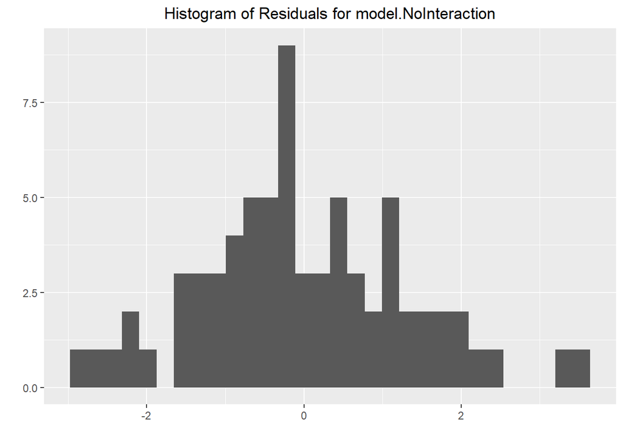

```r
# Plot location
setwd(figure_directory)

# Data to fit
data_modified_team <- team_data %>%
  select(TeamScore,
         params$dependent_response_team,
         params$dependent_response_DominateStrategy,
         Target,
         SessionOrder,
         Team)

# Generate models with variable response
GA_data_focus_team <- data_modified_team %>%
  filter(.data[[params$dependent_response_DominateStrategy]] == params$Strategy_GA_name_WithSpace)

model.NoInteraction <- model_data_Target_Session(df = GA_data_focus_team, dependent =  params$dependent_response_team, model.type =  "NoInteraction", is.team = TRUE, is.robust = FALSE)

# Histogram of Residuals - model.NoInteraction
ggplot(model.NoInteraction, aes(x = .resid)) +
  geom_histogram(bins = 30) +
  labs(title = paste("Histogram of Residuals for model.NoInteraction"), x = "", y = "") +
  theme(plot.title = element_text(hjust = 0.5)) +
  ggsave(filename = paste("Histogram_Residuals_", params$dependent_response_name_NoSpace, "_NoInteraction_", params$Strategy_GA_name_NoSpace, "_Team.png", sep = ""))
```

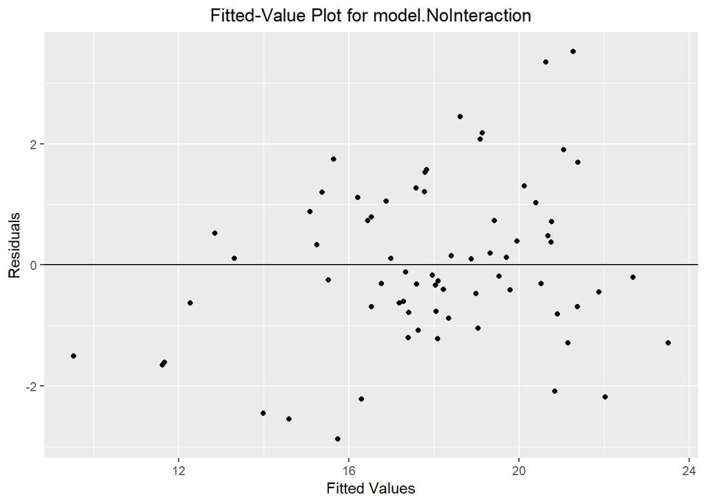

```r
# Fitted values - model.NoInteraction
ggplot(model.NoInteraction, aes(x = .fitted, y = .resid)) +
  geom_point() +
  geom_hline(yintercept = 0)+
  labs(title = paste("Fitted-Value Plot for model.NoInteraction"), x = "Fitted Values", y = "Residuals") +
  theme(plot.title = element_text(hjust = 0.5)) +
  ggsave(filename = paste("FitteValue_Residuals_", params$dependent_response_name_NoSpace, "_NoInteraction_", params$Strategy_GA_name_NoSpace, "_Team.png", sep = ""))
```

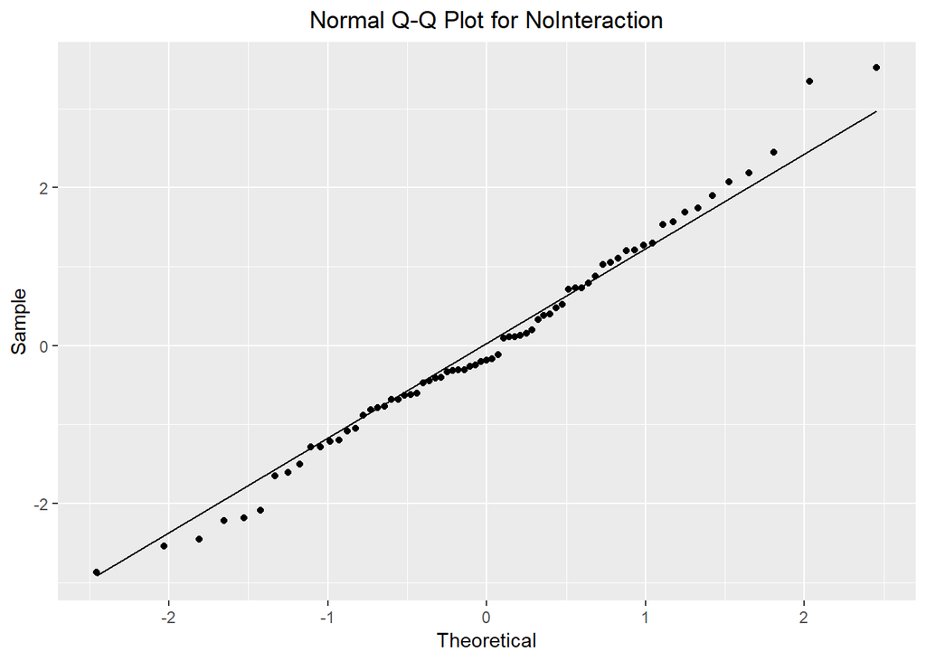

```r
# QQ plots - model.NoInteraction
ggplot(model.NoInteraction, aes(sample = .resid)) +
  stat_qq() +
  stat_qq_line()+
  labs(title = "Normal Q-Q Plot for NoInteraction", x = "Theoretical", y = "Sample") +
   theme(plot.title = element_text(hjust = 0.5)) +
  ggsave(filename = paste("QQ_Residuals_", params$dependent_response_name_NoSpace, "_NoInteraction_", params$Strategy_GA_name_NoSpace, "_Team.png", sep = ""))
```

It looks like there may be a violation with assumption 2 and a slight violation of assumption 3.

#### GT

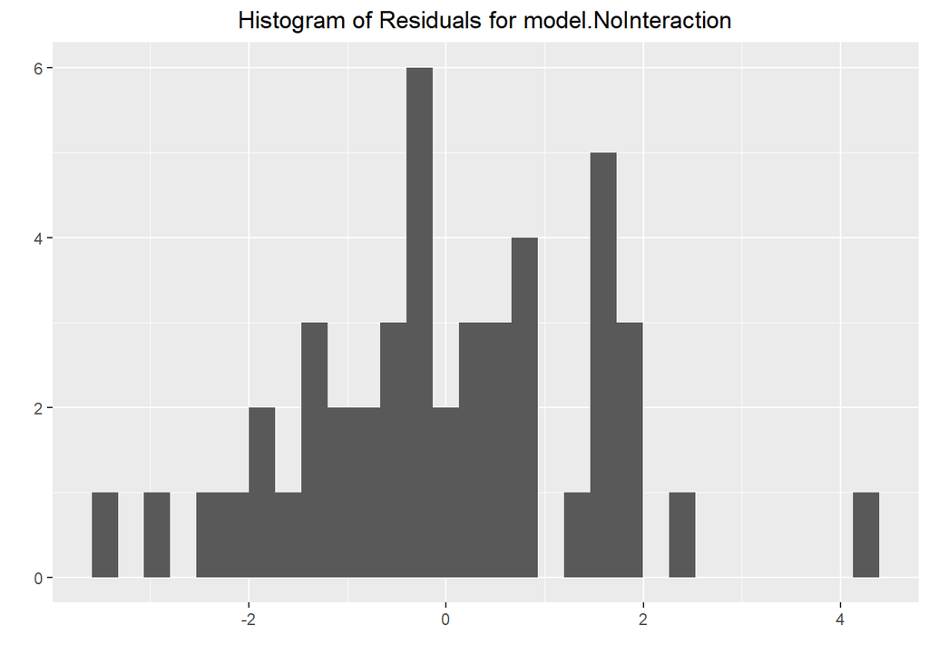

```r
# Plot location
setwd(figure_directory)

# Data to fit
data_modified_team <- team_data %>%
  select(TeamScore,
         params$dependent_response_team,
         params$dependent_response_DominateStrategy,
         Target,
         SessionOrder,
         Team)

# Generate models with variable response
GT_data_focus_team <- data_modified_team %>%
  filter(.data[[params$dependent_response_DominateStrategy]] == params$Strategy_GT_name_WithSpace)

model.NoInteraction <- model_data_Target_Session(df = GT_data_focus_team, dependent =  params$dependent_response_team, model.type =  "NoInteraction", is.team = TRUE, is.robust = FALSE)

# Histogram of Residuals - model.NoInteraction
ggplot(model.NoInteraction, aes(x = .resid)) +
  geom_histogram(bins = 30) +
  labs(title = paste("Histogram of Residuals for model.NoInteraction"), x = "", y = "") +
  theme(plot.title = element_text(hjust = 0.5)) +
  ggsave(filename = paste("Histogram_Residuals_", params$dependent_response_name_NoSpace, "_NoInteraction_", params$Strategy_GT_name_NoSpace, "_Team.png", sep = ""))
```

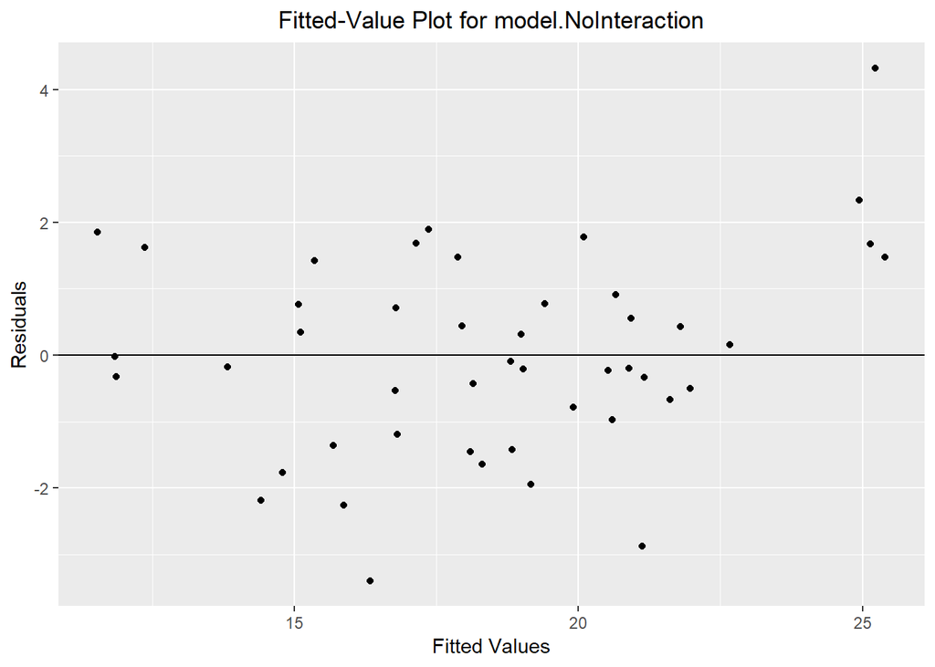

```r
# Fitted values - model.NoInteraction
ggplot(model.NoInteraction, aes(x = .fitted, y = .resid)) +
  geom_point() +
  geom_hline(yintercept = 0)+
  labs(title = paste("Fitted-Value Plot for model.NoInteraction"), x = "Fitted Values", y = "Residuals") +
  theme(plot.title = element_text(hjust = 0.5)) +
  ggsave(filename = paste("FitteValue_Residuals_", params$dependent_response_name_NoSpace, "_NoInteraction_", params$Strategy_GT_name_NoSpace, "_Team.png", sep = ""))
```

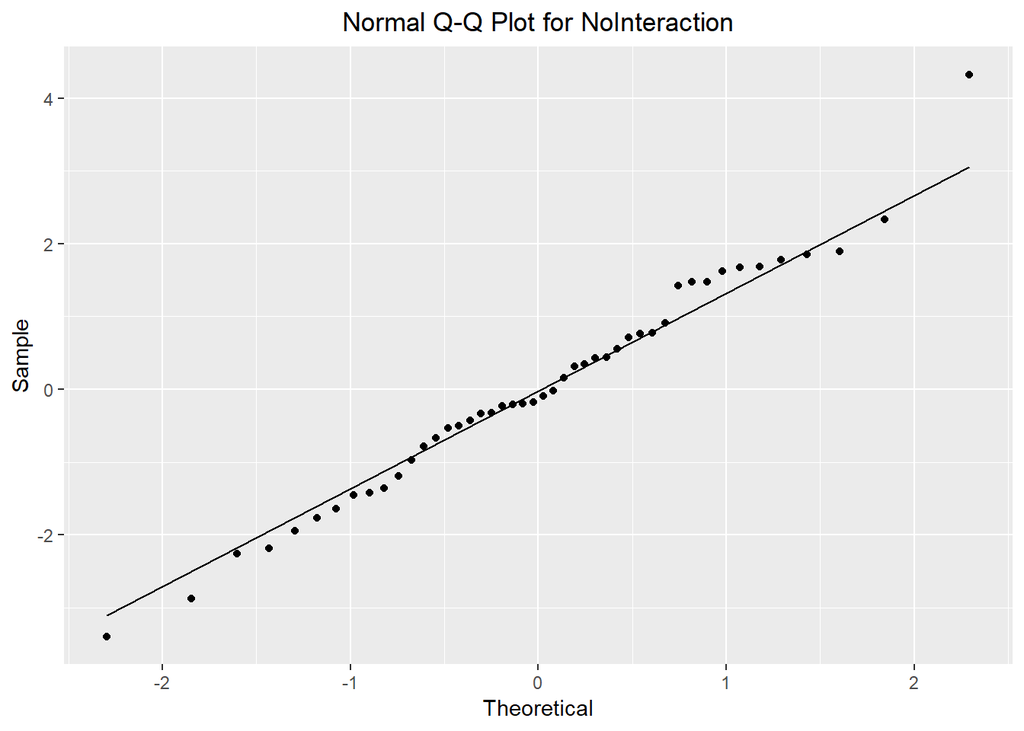

```r
# QQ plots - model.NoInteraction
ggplot(model.NoInteraction, aes(sample = .resid)) +
  stat_qq() +
  stat_qq_line()+
  labs(title = "Normal Q-Q Plot for NoInteraction", x = "Theoretical", y = "Sample") +
   theme(plot.title = element_text(hjust = 0.5)) +
  ggsave(filename = paste("QQ_Residuals_", params$dependent_response_name_NoSpace, "_NoInteraction_", params$Strategy_GT_name_NoSpace, "_Team.png", sep = ""))
```

There may be a violation of assumption 1.

### model.NoInteraction.NoTarget

#### GA

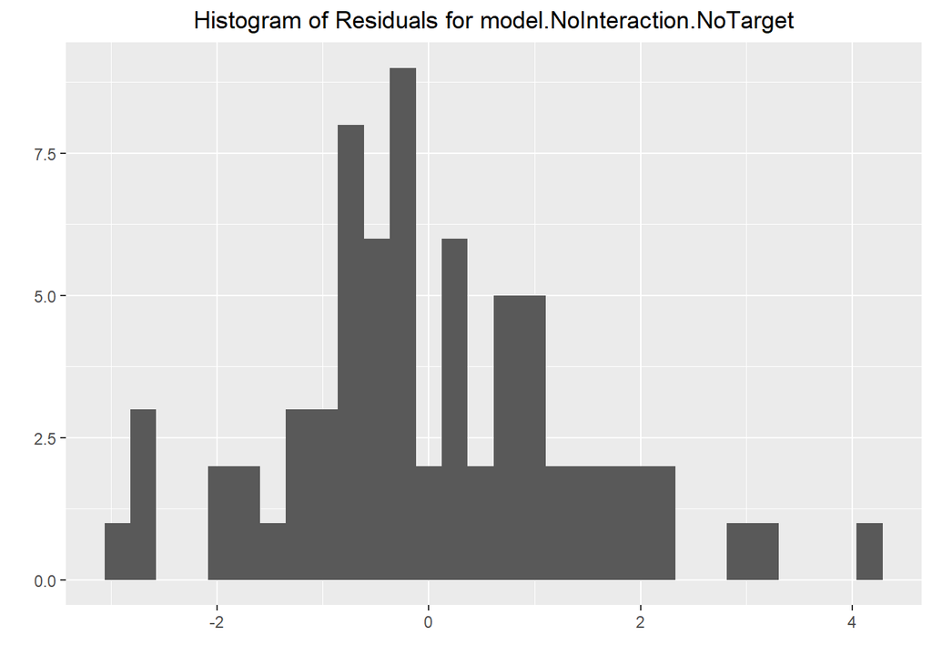

```r
# Plot location
setwd(figure_directory)

# Data to fit
data_modified_team <- team_data %>%
  select(TeamScore,
         params$dependent_response_team,
         params$dependent_response_DominateStrategy,
         Target,
         SessionOrder,
         Team)

# Generate models with variable response
GA_data_focus_team <- data_modified_team %>%
  filter(.data[[params$dependent_response_DominateStrategy]] == params$Strategy_GA_name_WithSpace)

model.NoInteraction.NoTarget <- model_data_Target_Session(df = GA_data_focus_team, dependent =  params$dependent_response_team, model.type =  "NoInteraction_NoTarget", is.team = TRUE, is.robust = FALSE)

# Histogram of Residuals - model.NoInteraction.NoTarget
ggplot(model.NoInteraction.NoTarget, aes(x = .resid)) +
  geom_histogram(bins = 30) +
  labs(title = paste("Histogram of Residuals for model.NoInteraction.NoTarget"), x = "", y = "") +
  theme(plot.title = element_text(hjust = 0.5)) +
  ggsave(filename = paste("Histogram_Residuals_", params$dependent_response_name_NoSpace, "_NoInteraction_", params$Strategy_GA_name_NoSpace, "_Team.png", sep = ""))
```

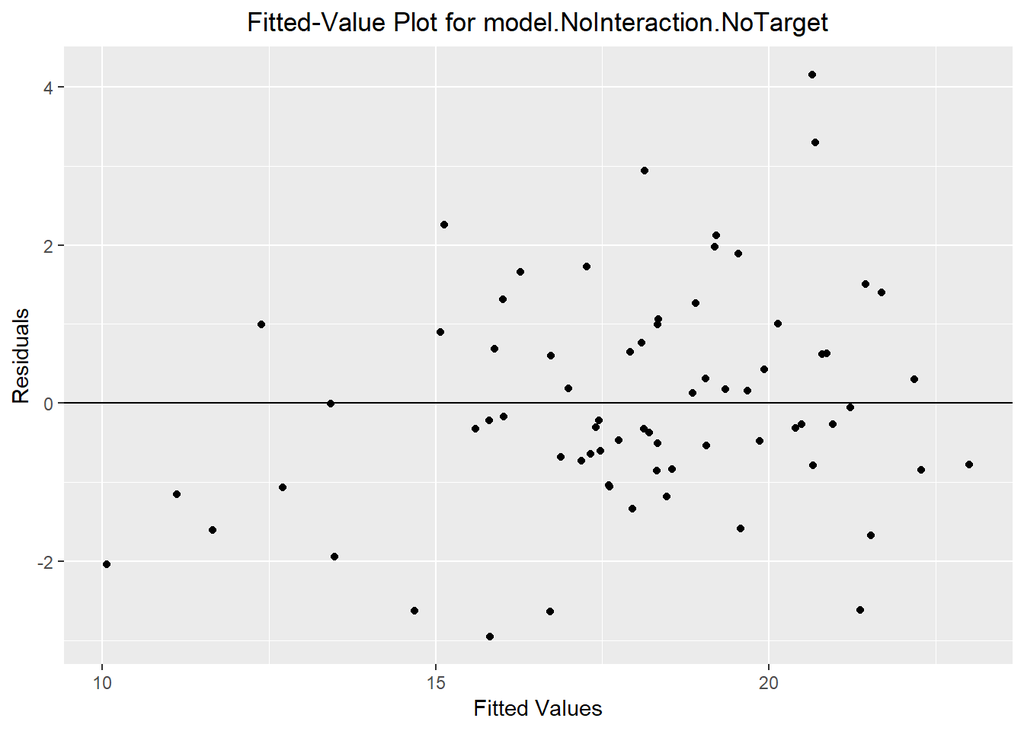

```r
# Fitted values - model.NoInteraction.NoTarget
ggplot(model.NoInteraction.NoTarget, aes(x = .fitted, y = .resid)) +
  geom_point() +
  geom_hline(yintercept = 0)+
  labs(title = paste("Fitted-Value Plot for model.NoInteraction.NoTarget"), x = "Fitted Values", y = "Residuals") +
  theme(plot.title = element_text(hjust = 0.5)) +
  ggsave(filename = paste("FitteValue_Residuals_", params$dependent_response_name_NoSpace, "_NoInteraction_", params$Strategy_GA_name_NoSpace, "_Team.png", sep = ""))
```

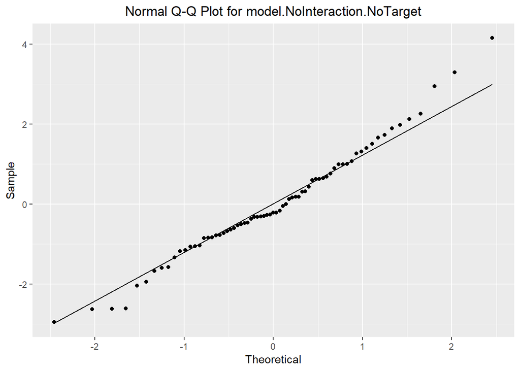

```r
# QQ plots - model.NoInteraction.NoTarget
ggplot(model.NoInteraction.NoTarget, aes(sample = .resid)) +
  stat_qq() +
  stat_qq_line()+
  labs(title = "Normal Q-Q Plot for model.NoInteraction.NoTarget", x = "Theoretical", y = "Sample") +
   theme(plot.title = element_text(hjust = 0.5)) +
  ggsave(filename = paste("QQ_Residuals_", params$dependent_response_name_NoSpace, "_NoInteraction_", params$Strategy_GA_name_NoSpace, "_Team.png", sep = ""))
```

There seems to be a violation of asumption 3.

#### GT

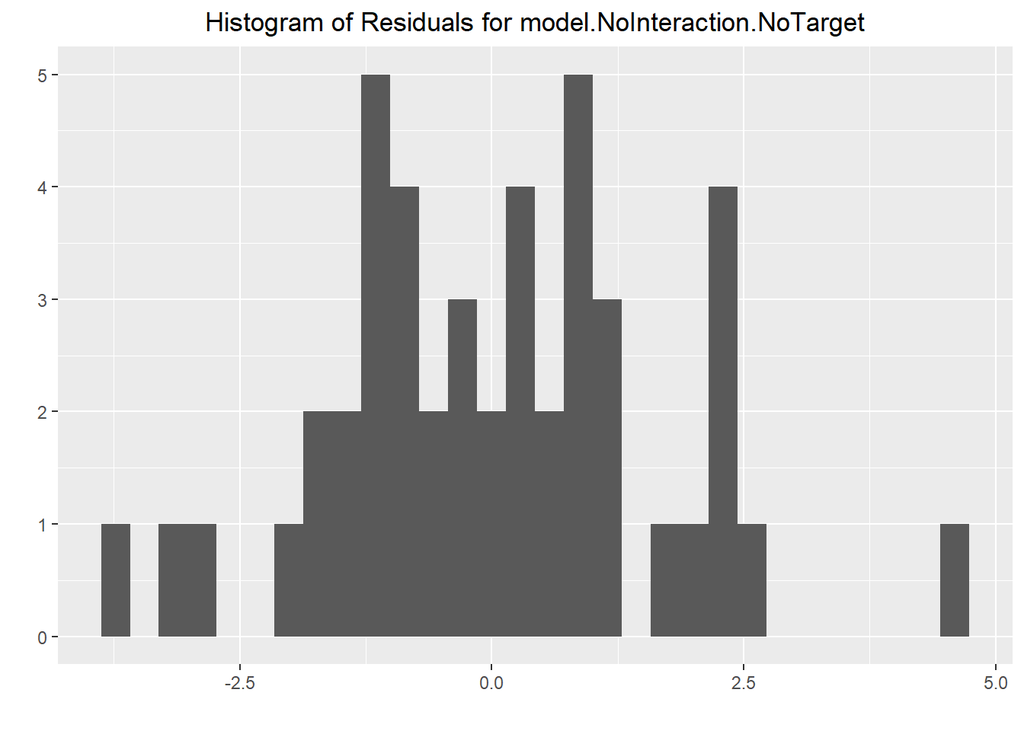

```r
# Plot location
setwd(figure_directory)

# Data to fit
data_modified_team <- team_data %>%
  select(TeamScore,
         params$dependent_response_team,
         params$dependent_response_DominateStrategy,
         Target,
         SessionOrder,
         Team)

# Generate models with variable response
GT_data_focus_team <- data_modified_team %>%
  filter(.data[[params$dependent_response_DominateStrategy]] == params$Strategy_GT_name_WithSpace)

model.NoInteraction.NoTarget <- model_data_Target_Session(df = GT_data_focus_team, dependent =  params$dependent_response_team, model.type =  "NoInteraction_NoTarget", is.team = TRUE, is.robust = FALSE)

# Histogram of Residuals - model.NoInteraction.NoTarget
ggplot(model.NoInteraction.NoTarget, aes(x = .resid)) +
  geom_histogram(bins = 30) +
  labs(title = paste("Histogram of Residuals for model.NoInteraction.NoTarget"), x = "", y = "") +
  theme(plot.title = element_text(hjust = 0.5)) +
  ggsave(filename = paste("Histogram_Residuals_", params$dependent_response_name_NoSpace, "_NoInteraction_", params$Strategy_GT_name_NoSpace, "_Team.png", sep = ""))
```

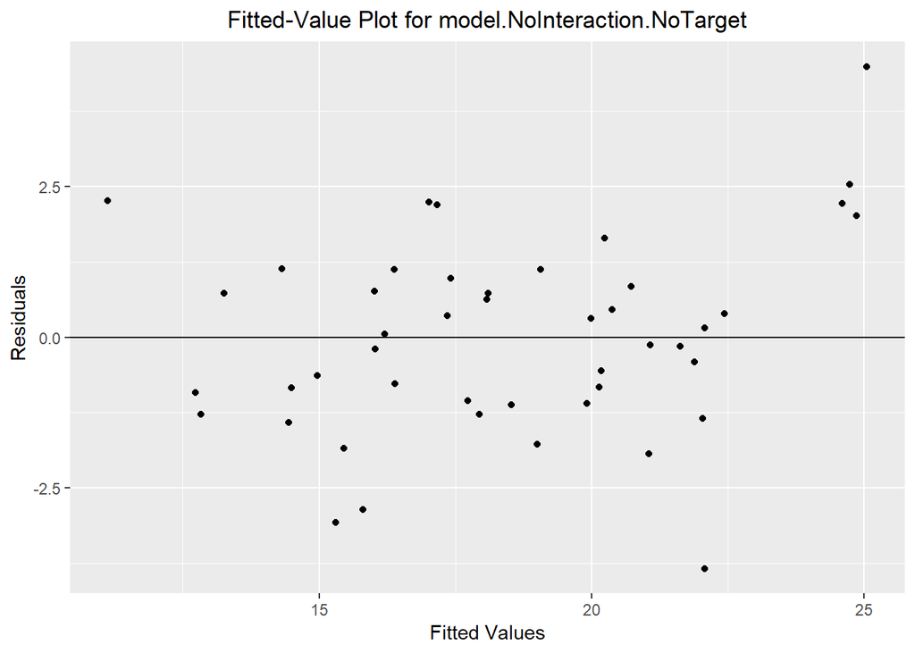

```r
# Fitted values - model.NoInteraction.NoTarget
ggplot(model.NoInteraction.NoTarget, aes(x = .fitted, y = .resid)) +
  geom_point() +
  geom_hline(yintercept = 0)+
  labs(title = paste("Fitted-Value Plot for model.NoInteraction.NoTarget"), x = "Fitted Values", y = "Residuals") +
  theme(plot.title = element_text(hjust = 0.5)) +
  ggsave(filename = paste("FitteValue_Residuals_", params$dependent_response_name_NoSpace, "_NoInteraction_", params$Strategy_GT_name_NoSpace, "_Team.png", sep = ""))
```

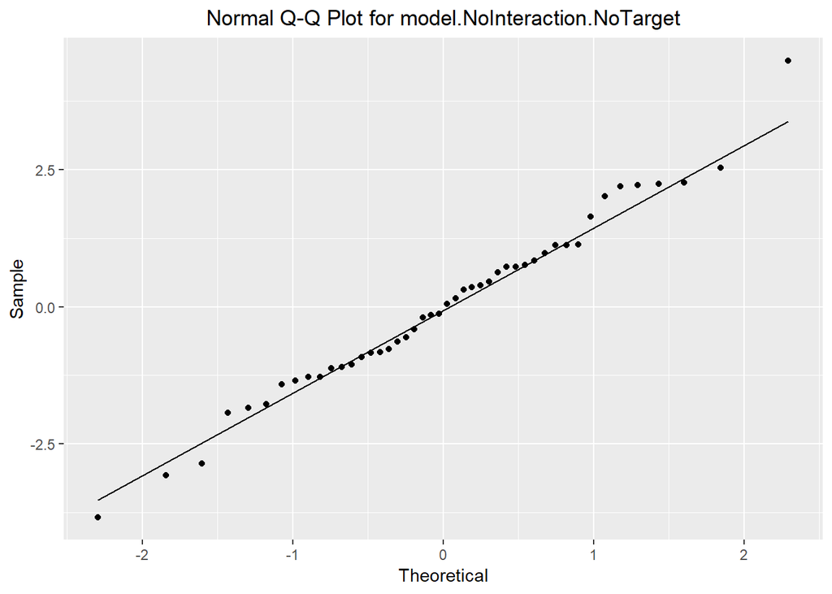

```r
# QQ plots - model.NoInteraction.NoTarget
ggplot(model.NoInteraction.NoTarget, aes(sample = .resid)) +
  stat_qq() +
  stat_qq_line()+
  labs(title = "Normal Q-Q Plot for model.NoInteraction.NoTarget", x = "Theoretical", y = "Sample") +
   theme(plot.title = element_text(hjust = 0.5)) +
  ggsave(filename = paste("QQ_Residuals_", params$dependent_response_name_NoSpace, "_NoInteraction_", params$Strategy_GT_name_NoSpace, "_Team.png", sep = ""))
```

Generally there seems to be no violtation, but I will still compare the reobust model to the classic model because of the tail end on the far right.

## Individual

### model.NoInteraction

#### GA

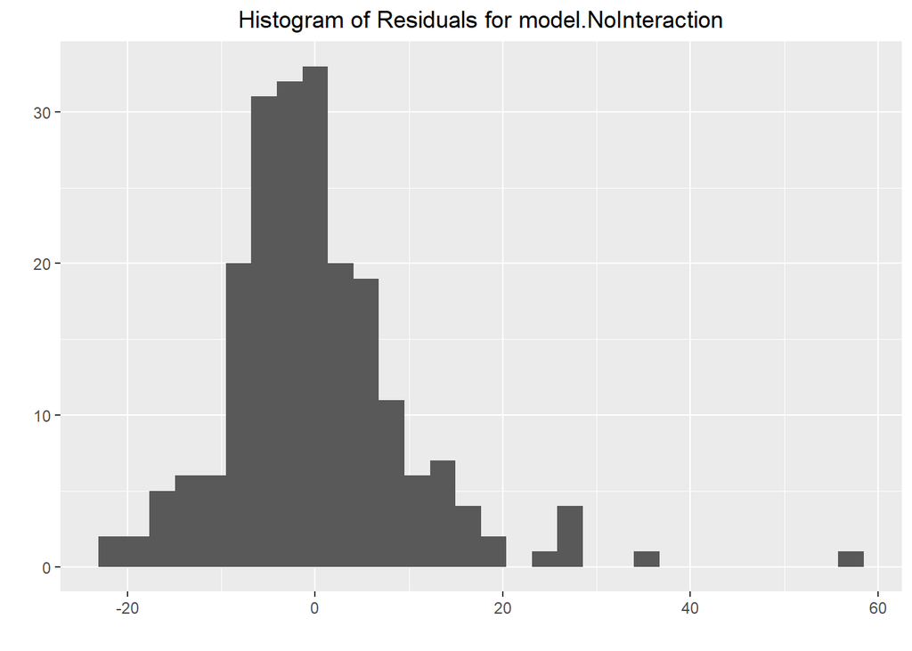

```r
# Plot location
setwd(figure_directory)

# Data to model
data_modified_ind <- ind_data %>%
  select(params$dependent_response_ind,
         params$dependent_response_DominateStrategy,
         Target,
         SessionOrder,
         Team,
         Player_ID)

# Generate models with variable response
GA_data_focus_ind <- data_modified_ind %>%
  filter(.data[[params$dependent_response_DominateStrategy]] == params$Strategy_GA_name_WithSpace)

model.NoInteraction <- model_data_Target_Session(df = GA_data_focus_ind, dependent =  params$dependent_response_ind, model.type =  "NoInteraction", is.team = FALSE, is.robust = FALSE)

# Histogram of Residuals - model.NoInteraction
ggplot(model.NoInteraction, aes(x = .resid)) +
  geom_histogram(bins = 30) +
  labs(title = paste("Histogram of Residuals for model.NoInteraction"), x = "", y = "") +
  theme(plot.title = element_text(hjust = 0.5)) +
  ggsave(paste("Histogram_Residuals_", params$dependent_response_name_NoSpace, "_NoInteraction_", params$Strategy_GA_name_NoSpace, "_Ind.png", sep =""))
```

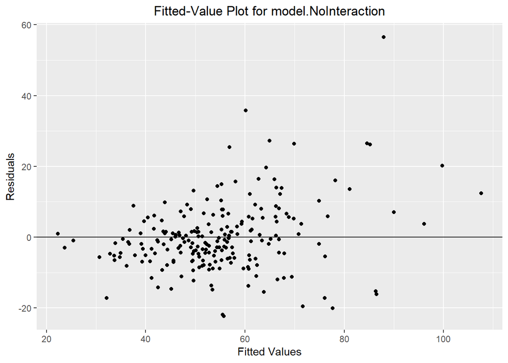

```r
# Fitted values - model.NoInteraction
ggplot(model.NoInteraction, aes(x = .fitted, y = .resid)) +
  geom_point() +
  geom_hline(yintercept = 0)+
  labs(title = paste("Fitted-Value Plot for model.NoInteraction"), x = "Fitted Values", y = "Residuals") +
  theme(plot.title = element_text(hjust = 0.5)) +
  ggsave(paste("FittedValue_Residuals_", params$dependent_response_name_NoSpace, "_NoInteraction_", params$Strategy_GA_name_NoSpace, "_Ind.png", sep =""))
```

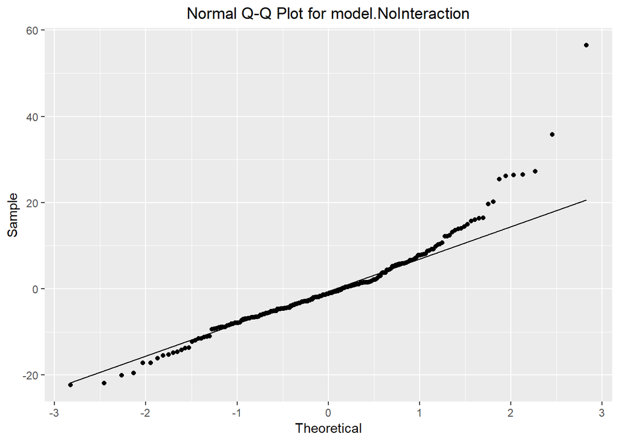

```r
# QQ plots - model.NoInteraction
ggplot(model.NoInteraction, aes(sample = .resid)) +
  stat_qq() +
  stat_qq_line()+
  labs(title = "Normal Q-Q Plot for model.NoInteraction", x = "Theoretical", y = "Sample") +
   theme(plot.title = element_text(hjust = 0.5)) +
  ggsave(paste("QQ_Residuals_", params$dependent_response_name_NoSpace, "_NoInteraction_", params$Strategy_GA_name_NoSpace, "_Ind.png", sep =""))
```

There seems to be a violation of assumption 2 and 3.

#### GT

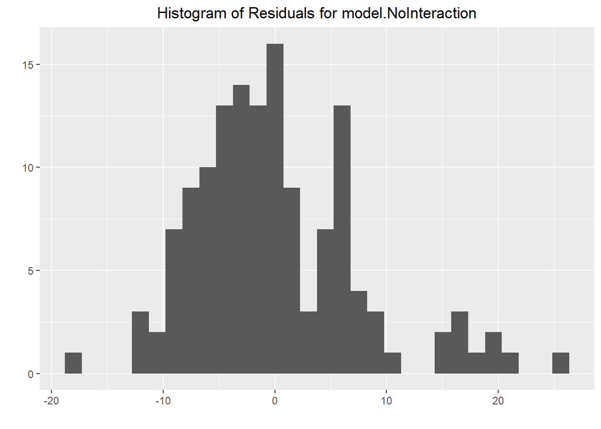

```r
# Plot location
setwd(figure_directory)

# Data to model
data_modified_ind <- ind_data %>%
  select(params$dependent_response_ind,
         params$dependent_response_DominateStrategy,
         Target,
         SessionOrder,
         Team,
         Player_ID)

# Generate models with variable response
GT_data_focus_ind <- data_modified_ind %>%
  filter(.data[[params$dependent_response_DominateStrategy]] == params$Strategy_GT_name_WithSpace)

model.NoInteraction <- model_data_Target_Session(df = GT_data_focus_ind, dependent =  params$dependent_response_ind, model.type =  "NoInteraction", is.team = FALSE, is.robust = FALSE)

# Histogram of Residuals - model.NoInteraction
ggplot(model.NoInteraction, aes(x = .resid)) +
  geom_histogram(bins = 30) +
  labs(title = paste("Histogram of Residuals for model.NoInteraction"), x = "", y = "") +
  theme(plot.title = element_text(hjust = 0.5)) +
  ggsave(paste("Histogram_Residuals_", params$dependent_response_name_NoSpace, "_NoInteraction_", params$Strategy_GT_name_NoSpace , "Ind.png", sep =""))
```

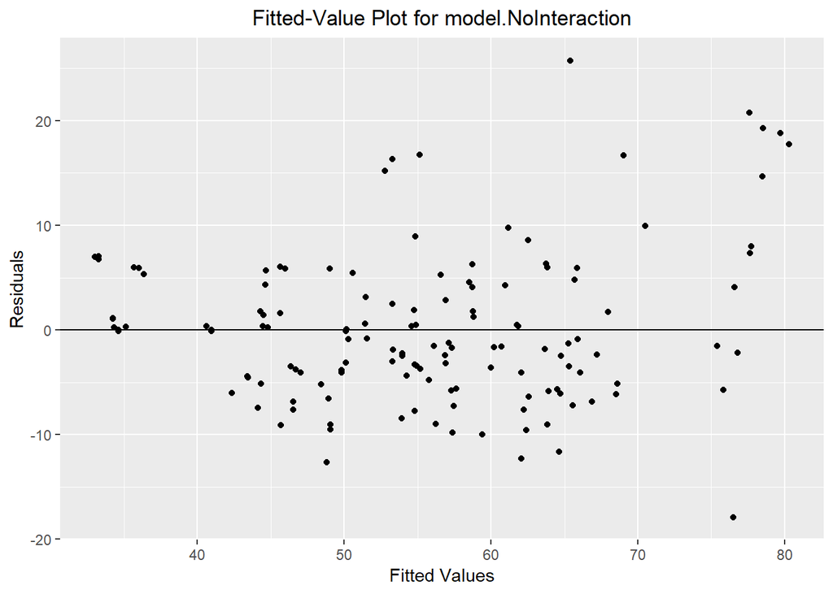

```r
# Fitted values - model.NoInteraction
ggplot(model.NoInteraction, aes(x = .fitted, y = .resid)) +
  geom_point() +
  geom_hline(yintercept = 0)+
  labs(title = paste("Fitted-Value Plot for model.NoInteraction"), x = "Fitted Values", y = "Residuals") +
  theme(plot.title = element_text(hjust = 0.5)) +
  ggsave(paste("FittedValue_Residuals_", params$dependent_response_name_NoSpace, "_NoInteraction_", params$Strategy_GT_name_NoSpace , "Ind.png", sep =""))
```

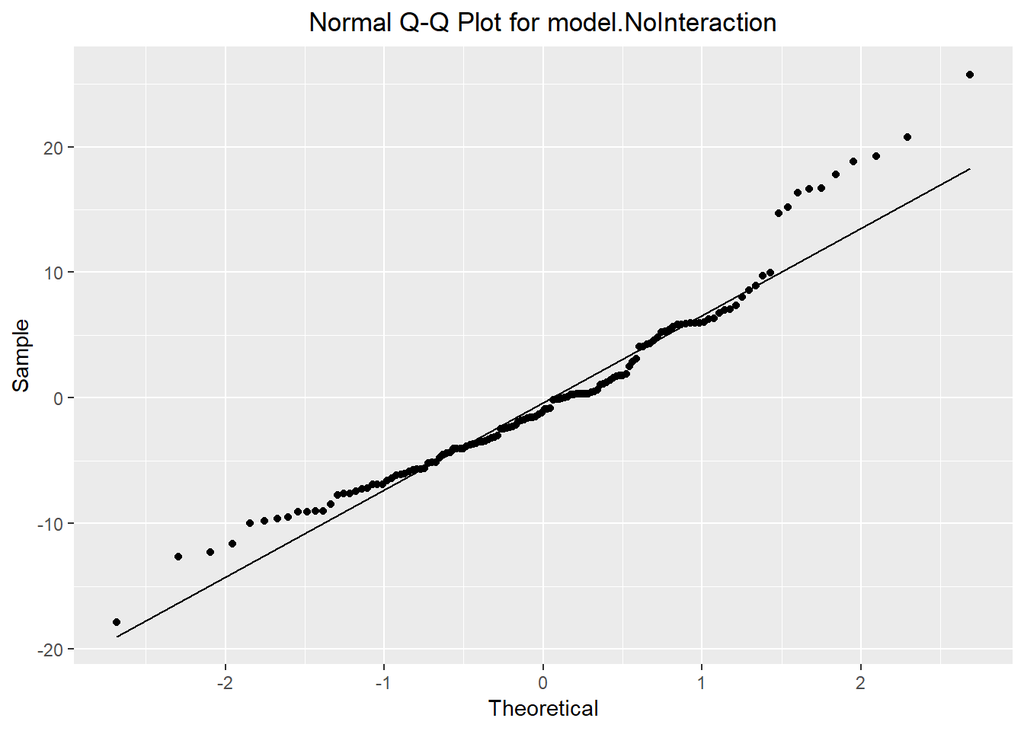

```r
# QQ plots - model.NoInteraction
ggplot(model.NoInteraction, aes(sample = .resid)) +
  stat_qq() +
  stat_qq_line()+
  labs(title = "Normal Q-Q Plot for model.NoInteraction", x = "Theoretical", y = "Sample") +
   theme(plot.title = element_text(hjust = 0.5)) +
  ggsave(paste("QQ_Residuals_", params$dependent_response_name_NoSpace, "_NoInteraction_", params$Strategy_GT_name_NoSpace , "Ind.png", sep =""))
```

There seems to be a violation with assumption 3.

### model.NoInteraction.NoTarget

#### GA

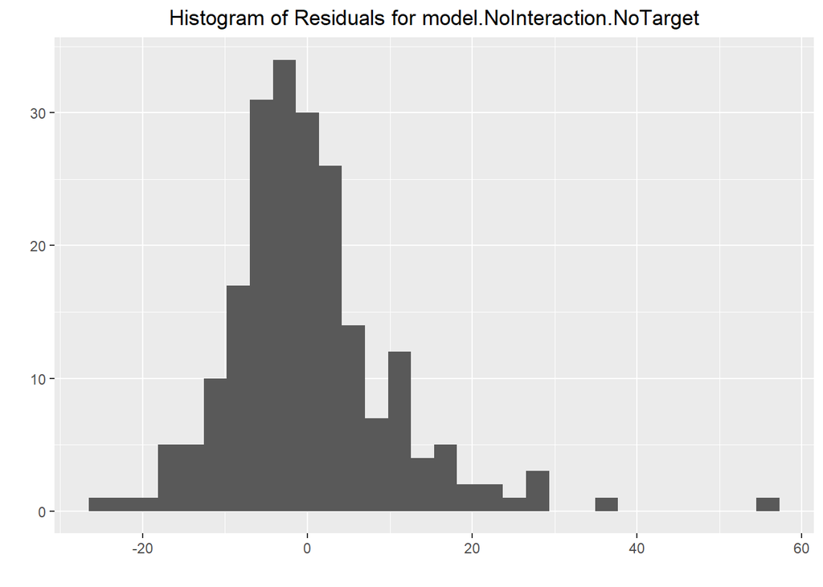

```r
# Plot location
setwd(figure_directory)

# Data to model
data_modified_ind <- ind_data %>%
  select(params$dependent_response_ind,
         params$dependent_response_DominateStrategy,
         Target,
         SessionOrder,
         Team,
         Player_ID)

# Generate models with variable response
GA_data_focus_ind <- data_modified_ind %>%
  filter(.data[[params$dependent_response_DominateStrategy]] == params$Strategy_GA_name_WithSpace)

model.NoInteraction.NoTarget <- model_data_Target_Session(df = GA_data_focus_ind, dependent =  params$dependent_response_ind, model.type =  "NoInteraction_NoTarget", is.team = FALSE, is.robust = FALSE)

# Histogram of Residuals - model.NoInteraction.NoTarget
ggplot(model.NoInteraction.NoTarget, aes(x = .resid)) +
  geom_histogram(bins = 30) +
  labs(title = paste("Histogram of Residuals for model.NoInteraction.NoTarget"), x = "", y = "") +
  theme(plot.title = element_text(hjust = 0.5)) +
  ggsave(paste("Histogram_Residuals_", params$dependent_response_name_NoSpace, "_NoInteractionNoTarget_", params$Strategy_GA_name_NoSpace, "_Ind.png", sep =""))
```

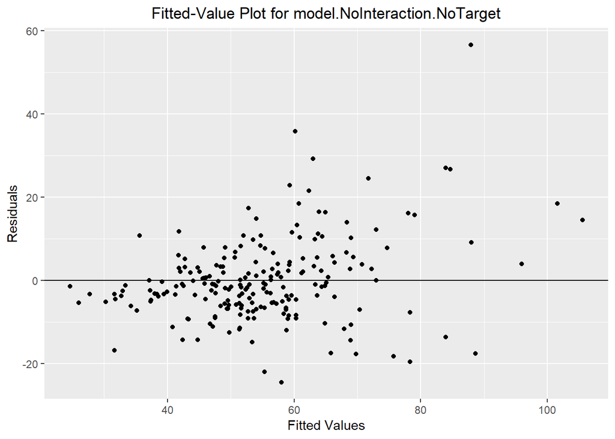

```r
# Fitted values - model.NoInteraction.NoTarget
ggplot(model.NoInteraction.NoTarget, aes(x = .fitted, y = .resid)) +
  geom_point() +
  geom_hline(yintercept = 0)+
  labs(title = paste("Fitted-Value Plot for model.NoInteraction.NoTarget"), x = "Fitted Values", y = "Residuals") +
  theme(plot.title = element_text(hjust = 0.5)) +
  ggsave(paste("FittedValue_Residuals_", params$dependent_response_name_NoSpace, "_NoInteractionNoTarget_", params$Strategy_GA_name_NoSpace, "_Ind.png", sep =""))
```

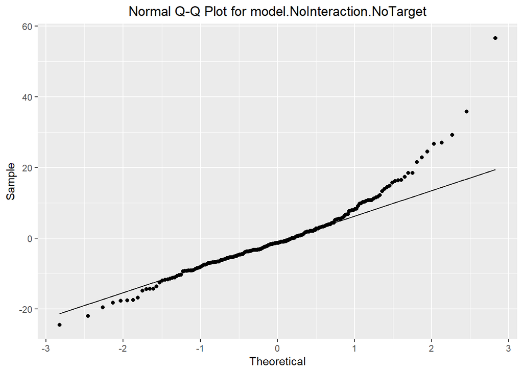

```r
# QQ plots - model.NoInteraction.NoTarget
ggplot(model.NoInteraction.NoTarget, aes(sample = .resid)) +
  stat_qq() +
  stat_qq_line()+
  labs(title = "Normal Q-Q Plot for model.NoInteraction.NoTarget", x = "Theoretical", y = "Sample") +
   theme(plot.title = element_text(hjust = 0.5)) +
  ggsave(paste("QQ_Residuals_", params$dependent_response_name_NoSpace, "_NoInteractionNoTarget_", params$Strategy_GA_name_NoSpace, "_Ind.png", sep =""))
```

There seems to be a violation of assumption 2 and 3.

#### GT

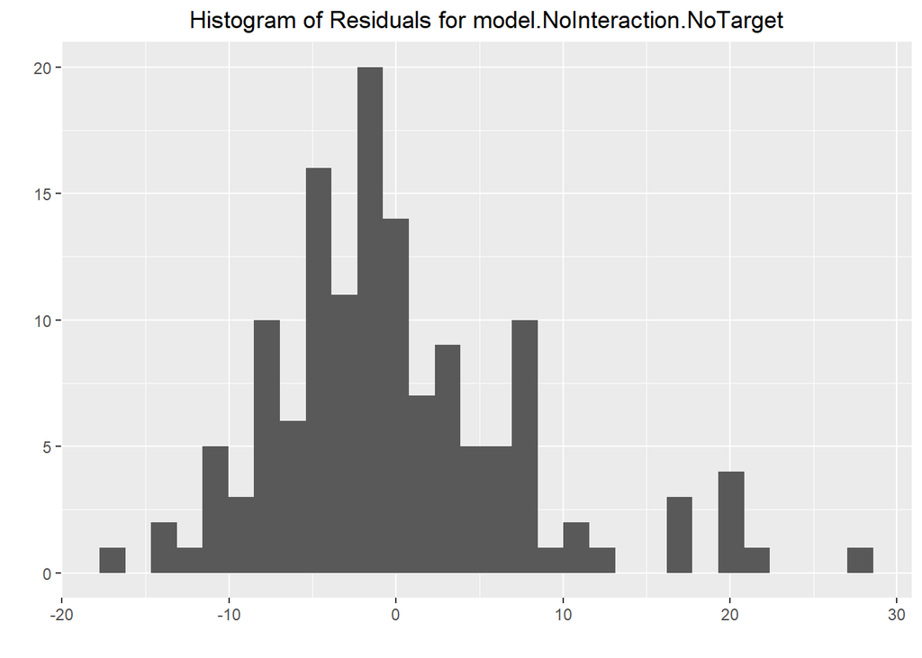

```r
# Plot location
setwd(figure_directory)

# Data to model
data_modified_ind <- ind_data %>%
  select(params$dependent_response_ind,
         params$dependent_response_DominateStrategy,
         Target,
         SessionOrder,
         Team,
         Player_ID)

# Generate models with variable response
GT_data_focus_ind <- data_modified_ind %>%
  filter(.data[[params$dependent_response_DominateStrategy]] == params$Strategy_GT_name_WithSpace)

model.NoInteraction.NoTarget <- model_data_Target_Session(df = GT_data_focus_ind, dependent =  params$dependent_response_ind, model.type =  "NoInteraction_NoTarget", is.team = FALSE, is.robust = FALSE)

# Histogram of Residuals - model.NoInteraction.NoTarget
ggplot(model.NoInteraction.NoTarget, aes(x = .resid)) +
  geom_histogram(bins = 30) +
  labs(title = paste("Histogram of Residuals for model.NoInteraction.NoTarget"), x = "", y = "") +
  theme(plot.title = element_text(hjust = 0.5)) +
  ggsave(paste("Histogram_Residuals_", params$dependent_response_name_NoSpace, "_NoInteractionNoTarget_", params$Strategy_GA_name_NoSpace, "_Ind.png", sep =""))
```

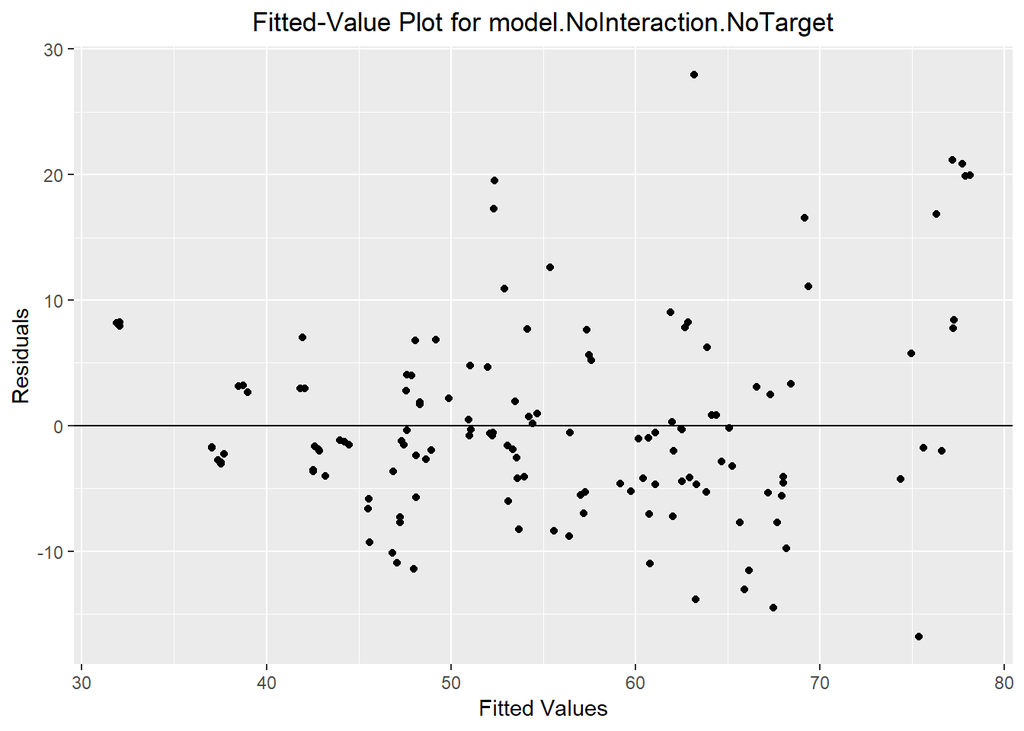

```r
# Fitted values - model.NoInteraction.NoTarget
ggplot(model.NoInteraction.NoTarget, aes(x = .fitted, y = .resid)) +
  geom_point() +
  geom_hline(yintercept = 0)+
  labs(title = paste("Fitted-Value Plot for model.NoInteraction.NoTarget"), x = "Fitted Values", y = "Residuals") +
  theme(plot.title = element_text(hjust = 0.5)) +
  ggsave(paste("FittedValue_Residuals_", params$dependent_response_name_NoSpace, "_NoInteractionNoTarget_", params$Strategy_GA_name_NoSpace, "_Ind.png", sep =""))
```

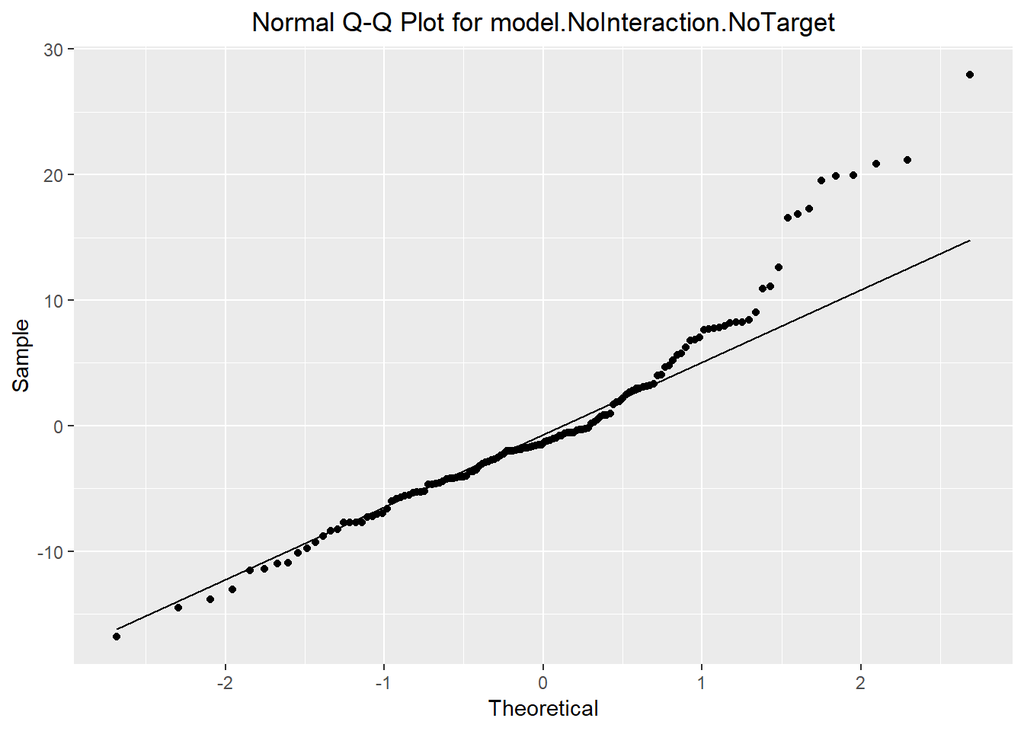

```r
# QQ plots - model.NoInteraction.NoTarget
ggplot(model.NoInteraction.NoTarget, aes(sample = .resid)) +
  stat_qq() +
  stat_qq_line()+
  labs(title = "Normal Q-Q Plot for model.NoInteraction.NoTarget", x = "Theoretical", y = "Sample") +
   theme(plot.title = element_text(hjust = 0.5)) +
  ggsave(paste("QQ_Residuals_", params$dependent_response_name_NoSpace, "_NoInteractionNoTarget_", params$Strategy_GA_name_NoSpace, "_Ind.png", sep =""))
```

There seems to be a vilotation to assumption 3.

# Q: Does the violation influence the linear model estimation?

## Team

### model.NoInteraction

#### GA

```r
# Data to fit
data_modified_team <- team_data %>%
  select(TeamScore,
         params$dependent_response_team,
         params$dependent_response_DominateStrategy,
         Target,
         SessionOrder,
         Team)

# Generate models with variable response
GA_data_focus_team <- data_modified_team %>%
  filter(.data[[params$dependent_response_DominateStrategy]] == params$Strategy_GA_name_WithSpace)

# Generate robust and non-robust models - NoInteraction
model.NoInteraction <- model_data_Target_Session(df = GA_data_focus_team, dependent =  params$dependent_response_team, model.type =  "NoInteraction", is.team = TRUE, is.robust = FALSE)
rmodel.NoInteraction <- model_data_Target_Session(df = GA_data_focus_team, dependent =  params$dependent_response_team, model.type =  "NoInteraction", is.team = TRUE, is.robust = TRUE)

comparision_results <- compare(model.NoInteraction, rmodel.NoInteraction, show.rho.functions = FALSE)

comparision_results %>%
  kable(caption = "model.NoInteraction") %>%
  kable_styling()
```

model.NoInteraction

|  | model.NoInteraction | rmodel.NoInteraction |
| --- | --- | --- |
| Coef |  |  |
| (Intercept) | 18.394 (0.683) | 18.669 (0.633) |
| TargetInd_Team | 1.032 (0.504) | 0.950 (0.486) |
| TargetTeam | 0.439 (0.505) | 0.445 (0.486) |
| SessionOrder3 | -0.601 (0.501) | -0.681 (0.483) |
| SessionOrder4 | -2.289 (0.506) | -2.227 (0.487) |
| VarComp |  |  |
| (Intercept) \| Team | 2.67 | 2.34 |
| sigma | 1.68 | 1.58 |
| REML | 322 |  |

I see no concerable difference. I will not transform data.

#### GT

```r
# Data to fit
data_modified_team <- team_data %>%
  select(TeamScore,
         params$dependent_response_team,
         params$dependent_response_DominateStrategy,
         Target,
         SessionOrder,
         Team)

# Generate models with variable response
GT_data_focus_team <- data_modified_team %>%
  filter(.data[[params$dependent_response_DominateStrategy]] == params$Strategy_GT_name_WithSpace)

# Generate robust and non-robust models - NoInteraction
model.NoInteraction <- model_data_Target_Session(df = GT_data_focus_team, dependent =  params$dependent_response_team, model.type =  "NoInteraction", is.team = TRUE, is.robust = FALSE)
rmodel.NoInteraction <- model_data_Target_Session(df = GT_data_focus_team, dependent =  params$dependent_response_team, model.type =  "NoInteraction", is.team = TRUE, is.robust = TRUE)

comparision_results <- compare(model.NoInteraction, rmodel.NoInteraction, show.rho.functions = FALSE)

comparision_results %>%
  kable(caption = "model.NoInteraction") %>%
  kable_styling()
```

model.NoInteraction

|  | model.NoInteraction | rmodel.NoInteraction |
| --- | --- | --- |
| Coef |  |  |
| (Intercept) | 22.131 (1.062) | 21.955 (1.067) |
| TargetInd_Team | -0.373 (0.746) | -0.601 (0.742) |
| TargetTeam | -1.680 (0.778) | -1.714 (0.775) |
| SessionOrder3 | -2.788 (0.790) | -2.600 (0.786) |
| SessionOrder4 | -4.427 (0.785) | -4.307 (0.782) |
| VarComp |  |  |
| (Intercept) \| Team | 3.48 | 3.43 |
| sigma | 1.98 | 1.92 |
| REML | 221 |  |

I see no concernable difference. I will not transform data.

### model.NoInteraction.NoTarget

#### GA

```r
# Data to fit
data_modified_team <- team_data %>%
  select(TeamScore,
         params$dependent_response_team,
         params$dependent_response_DominateStrategy,
         Target,
         SessionOrder,
         Team)

# Generate models with variable response
GA_data_focus_team <- data_modified_team %>%
  filter(.data[[params$dependent_response_DominateStrategy]] == params$Strategy_GA_name_WithSpace)

# Generate robust and non-robust models - NoInteraction
model.NoInteraction.NoTarget <- model_data_Target_Session(df = GA_data_focus_team, dependent =  params$dependent_response_team, model.type =  "NoInteraction_NoTarget", is.team = TRUE, is.robust = FALSE)
rmodel.NoInteraction.NoTarget <- model_data_Target_Session(df = GA_data_focus_team, dependent =  params$dependent_response_team, model.type =  "NoInteraction_NoTarget", is.team = TRUE, is.robust = TRUE)

comparision_results <- compare(model.NoInteraction.NoTarget, rmodel.NoInteraction.NoTarget, show.rho.functions = FALSE)

comparision_results %>%
  kable(caption = "model.NoInteraction.NoTarget") %>%
  kable_styling()
```

model.NoInteraction.NoTarget

|  | model.NoInteraction.NoTarget | rmodel.NoInteraction.NoTarget |
| --- | --- | --- |
| Coef |  |  |
| (Intercept) | 18.905 (0.619) | 19.12 (0.574) |
| SessionOrder3 | -0.726 (0.508) | -0.78 (0.486) |
| SessionOrder4 | -2.312 (0.516) | -2.25 (0.494) |
| VarComp |  |  |
| (Intercept) \| Team | 2.69 | 2.40 |
| sigma | 1.72 | 1.6 |
| REML | 327 |  |

I see no concernable difference. I will not transform data.

#### GT

```r
# Data to fit
data_modified_team <- team_data %>%
  select(TeamScore,
         params$dependent_response_team,
         params$dependent_response_DominateStrategy,
         Target,
         SessionOrder,
         Team)

# Generate models with variable response
GT_data_focus_team <- data_modified_team %>%
  filter(.data[[params$dependent_response_DominateStrategy]] == params$Strategy_GT_name_WithSpace)

# Generate robust and non-robust models - NoInteraction
model.NoInteraction.NoTarget <- model_data_Target_Session(df = GT_data_focus_team, dependent =  params$dependent_response_team, model.type =  "NoInteraction_NoTarget", is.team = TRUE, is.robust = FALSE)
rmodel.NoInteraction.NoTarget <- model_data_Target_Session(df = GT_data_focus_team, dependent =  params$dependent_response_team, model.type =  "NoInteraction_NoTarget", is.team = TRUE, is.robust = TRUE)

comparision_results <- compare(model.NoInteraction.NoTarget, rmodel.NoInteraction.NoTarget, show.rho.functions = FALSE)

comparision_results %>%
  kable(caption = "model.NoInteraction.NoTarget") %>%
  kable_styling()
```

model.NoInteraction.NoTarget

|  | model.NoInteraction.NoTarget | rmodel.NoInteraction.NoTarget |
| --- | --- | --- |
| Coef |  |  |
| (Intercept) | 21.61 (1.045) | 21.29 (1.049) |
| SessionOrder3 | -2.97 (0.802) | -2.72 (0.796) |
| SessionOrder4 | -4.68 (0.800) | -4.50 (0.793) |
| VarComp |  |  |
| (Intercept) \| Team | 3.61 | 3.55 |
| sigma | 2.05 | 1.98 |
| REML | 228 |  |

I see no concerable difference. I will not transform.

## Individual

### model.NoInteraction

#### GA

```r
#response_variable <- "II_ind"

# Data to model
data_modified_ind <- ind_data %>%
  select(params$dependent_response_ind,
         params$dependent_response_DominateStrategy,
         Target,
         SessionOrder,
         Team,
         Player_ID)

# Generate models with variable response
GA_data_focus_ind <- data_modified_ind %>%
  filter(.data[[params$dependent_response_DominateStrategy]] == params$Strategy_GA_name_WithSpace)

model.NoInteraction <- model_data_Target_Session(df = GA_data_focus_ind, dependent =  params$dependent_response_ind, model.type =  "NoInteraction", is.team = FALSE, is.robust = FALSE)
rmodel.NoInteraction <- model_data_Target_Session(df = GA_data_focus_ind, dependent =  params$dependent_response_ind, model.type =  "NoInteraction", is.team = FALSE, is.robust = TRUE)

comparision_results <- compare(model.NoInteraction, rmodel.NoInteraction, show.rho.functions = FALSE)

comparision_results %>%
  kable(caption = "model.NoInteraction") %>%
  kable_styling()
```

model.NoInteraction

|  | model.NoInteraction | rmodel.NoInteraction |
| --- | --- | --- |
| Coef |  |  |
| (Intercept) | 56.80 (2.64) | 55.28 (2.09) |
| TargetInd_Team | 4.34 (2.06) | 4.29 (1.61) |
| TargetTeam | 2.37 (2.06) | 1.10 (1.61) |
| SessionOrder3 | -3.47 (2.04) | -2.62 (1.60) |
| SessionOrder4 | -9.53 (2.06) | -8.61 (1.61) |
| VarComp |  |  |
| (Intercept) \| Player_ID | 11.92 | 8.79 |
| (Intercept) \| Team | 7.11 | 5.81 |
| sigma | 11.9 | 9.05 |
| REML | 1756 |  |

I see no concerable difference. I will not transform.

#### GT

```r
#response_variable <- "II_ind"

# Data to model
data_modified_ind <- ind_data %>%
  select(params$dependent_response_ind,
         params$dependent_response_DominateStrategy,
         Target,
         SessionOrder,
         Team,
         Player_ID)

# Generate models with variable response
GT_data_focus_ind <- data_modified_ind %>%
  filter(.data[[params$dependent_response_DominateStrategy]] == params$Strategy_GT_name_WithSpace)

model.NoInteraction <- model_data_Target_Session(df = GT_data_focus_ind, dependent =  params$dependent_response_ind, model.type =  "NoInteraction", is.team = FALSE, is.robust = FALSE)
rmodel.NoInteraction <- model_data_Target_Session(df = GT_data_focus_ind, dependent =  params$dependent_response_ind, model.type =  "NoInteraction", is.team = FALSE, is.robust = TRUE)

comparision_results <- compare(model.NoInteraction, rmodel.NoInteraction, show.rho.functions = FALSE)

comparision_results %>%
  kable(caption = "model.NoInteraction") %>%
  kable_styling()
```

model.NoInteraction

|  | model.NoInteraction | rmodel.NoInteraction |
| --- | --- | --- |
| Coef |  |  |
| (Intercept) | 67.78 (3.06) | 64.51 (2.92) |
| TargetInd_Team | -1.49 (1.79) | -1.07 (1.54) |
| TargetTeam | -5.41 (1.88) | -4.10 (1.61) |
| SessionOrder3 | -9.04 (1.90) | -7.51 (1.63) |
| SessionOrder4 | -14.30 (1.89) | -12.28 (1.63) |
| VarComp |  |  |
| (Intercept) \| Player_ID | 2.48 | 0.00 |
| (Intercept) \| Team | 10.95 | 10.61 |
| sigma | 8.2 | 6.86 |
| REML | 1007 |  |

I see no concernable difference. I will not transform the data.

### model.NoInteraction.NoTarget

#### GA

```r
#response_variable <- "II_ind"

# Data to model
data_modified_ind <- ind_data %>%
  select(params$dependent_response_ind,
         params$dependent_response_DominateStrategy,
         Target,
         SessionOrder,
         Team,
         Player_ID)

# Generate models with variable response
GA_data_focus_ind <- data_modified_ind %>%
  filter(.data[[params$dependent_response_DominateStrategy]] == params$Strategy_GA_name_WithSpace)

model.NoInteraction.NoTarget <- model_data_Target_Session(df = GA_data_focus_ind, dependent =  params$dependent_response_ind, model.type =  "NoInteraction_NoTarget", is.team = FALSE, is.robust = FALSE)
rmodel.NoInteraction.NoTarget <- model_data_Target_Session(df = GA_data_focus_ind, dependent =  params$dependent_response_ind, model.type =  "NoInteraction_NoTarget", is.team = FALSE, is.robust = TRUE)

comparision_results <- compare(model.NoInteraction.NoTarget, rmodel.NoInteraction.NoTarget, show.rho.functions = FALSE)

comparision_results %>%
  kable(caption = "model.NoInteraction.NoTarget") %>%
  kable_styling()
```

model.NoInteraction.NoTarget

|  | model.NoInteraction.NoTarget | rmodel.NoInteraction.NoTarget |
| --- | --- | --- |
| Coef |  |  |
| (Intercept) | 59.13 (2.35) | 57.30 (1.92) |
| SessionOrder3 | -3.98 (2.04) | -3.34 (1.62) |
| SessionOrder4 | -9.62 (2.08) | -8.84 (1.65) |
| VarComp |  |  |
| (Intercept) \| Player_ID | 11.88 | 8.19 |
| (Intercept) \| Team | 7.23 | 6.52 |
| sigma | 12 | 9.26 |
| REML | 1766 |  |

I see no concernable difference. I will not transform the data.

#### GT

```r
#response_variable <- "II_ind"

# Data to model
data_modified_ind <- ind_data %>%
  select(params$dependent_response_ind,
         params$dependent_response_DominateStrategy,
         Target,
         SessionOrder,
         Team,
         Player_ID)

# Generate models with variable response
GT_data_focus_ind <- data_modified_ind %>%
  filter(.data[[params$dependent_response_DominateStrategy]] == params$Strategy_GT_name_WithSpace)

model.NoInteraction.NoTarget <- model_data_Target_Session(df = GT_data_focus_ind, dependent =  params$dependent_response_ind, model.type =  "NoInteraction_NoTarget", is.team = FALSE, is.robust = FALSE)
rmodel.NoInteraction.NoTarget <- model_data_Target_Session(df = GT_data_focus_ind, dependent =  params$dependent_response_ind, model.type =  "NoInteraction_NoTarget", is.team = FALSE, is.robust = TRUE)

comparision_results <- compare(model.NoInteraction.NoTarget, rmodel.NoInteraction.NoTarget, show.rho.functions = FALSE)

comparision_results %>%
  kable(caption = "model.NoInteraction.NoTarget") %>%
  kable_styling()
```

model.NoInteraction.NoTarget

|  | model.NoInteraction.NoTarget | rmodel.NoInteraction.NoTarget |
| --- | --- | --- |
| Coef |  |  |
| (Intercept) | 66.07 (3.08) | 62.88 (2.89) |
| SessionOrder3 | -9.71 (1.92) | -7.66 (1.58) |
| SessionOrder4 | -15.20 (1.92) | -12.78 (1.58) |
| VarComp |  |  |
| (Intercept) \| Player_ID | 2.1 | 0.0 |
| (Intercept) \| Team | 11.4 | 10.9 |
| sigma | 8.47 | 6.78 |
| REML | 1022 |  |

I see no concerable difference. I will not transform the data

## Summary

Overall, the visual assumption violations did not not seem to influence the model for any of the models. I will not transform the data for any of the models.

# Q: Are there any effects that are significant?

## Team

### model.NoInteraction

#### GA

```r
# Data to fit
data_modified_team <- team_data %>%
  select(TeamScore,
         params$dependent_response_team,
         params$dependent_response_DominateStrategy,
         Target,
         SessionOrder,
         Team)

# Generate models with variable response
GA_data_focus_team <- data_modified_team %>%
  filter(.data[[params$dependent_response_DominateStrategy]] == params$Strategy_GA_name_WithSpace)

# Generate robust and non-robust models - NoInteraction
model.NoInteraction <- model_data_Target_Session(df = GA_data_focus_team, dependent =  params$dependent_response_team, model.type =  "NoInteraction", is.team = TRUE, is.robust = FALSE)

summary(model.NoInteraction)
```

```
## Linear mixed model fit by REML. t-tests use Satterthwaite's method [
## lmerModLmerTest]
## Formula:
## as.formula(paste(dependent, "~ Target + SessionOrder + (1|Team)"))
##    Data: df
##
## REML criterion at convergence: 322
##
## Scaled residuals:
##     Min      1Q  Median      3Q     Max
## -1.7089 -0.4638 -0.1092  0.4987  2.0991
##
## Random effects:
##  Groups   Name        Variance Std.Dev.
##  Team     (Intercept) 7.152    2.674
##  Residual             2.821    1.680
## Number of obs: 71, groups:  Team, 27
##
## Fixed effects:
##                Estimate Std. Error      df t value Pr(>|t|)
## (Intercept)     18.3936     0.6826 50.8937  26.948  < 2e-16 ***
## TargetInd_Team   1.0323     0.5042 42.4219   2.047   0.0468 *
## TargetTeam       0.4392     0.5051 43.2600   0.869   0.3894
## SessionOrder3   -0.6014     0.5013 43.2133  -1.200   0.2368
## SessionOrder4   -2.2893     0.5057 43.1161  -4.527 4.67e-05 ***
## ---
## Signif. codes:  0 '***' 0.001 '**' 0.01 '*' 0.05 '.' 0.1 ' ' 1
##
## Correlation of Fixed Effects:
##             (Intr) TrgI_T TrgtTm SssnO3
## TargtInd_Tm -0.386
## TargetTeam  -0.380  0.505
## SessinOrdr3 -0.364  0.120  0.035
## SessinOrdr4 -0.328  0.022  0.003  0.496
```

The results show a significant effect from Ind_Team condition in reference to the Ind condition. The results show a significant effect from session 4 in reference to the session 2.

```r
# Data to fit
data_modified_team <- team_data %>%
  select(TeamScore,
         params$dependent_response_team,
         params$dependent_response_DominateStrategy,
         Target,
         SessionOrder,
         Team)

# Generate models with variable response
GA_data_focus_team <- data_modified_team %>%
  filter(.data[[params$dependent_response_DominateStrategy]] == params$Strategy_GA_name_WithSpace)

# Generate robust and non-robust models - NoInteraction
model.NoInteraction <- model_data_Target_Session(df = GA_data_focus_team, dependent =  params$dependent_response_team, model.type =  "NoInteraction", is.team = TRUE, is.robust = FALSE)

emmeans(model.NoInteraction, list(pairwise ~ Target), adjust = "tukey")
```

```
## $`emmeans of Target`
##  Target   emmean    SE   df lower.CL upper.CL
##  Ind        17.4 0.626 39.2     16.2     18.7
##  Ind_Team   18.5 0.636 40.6     17.2     19.7
##  Team       17.9 0.626 39.2     16.6     19.1
##
## Results are averaged over the levels of: SessionOrder
## Degrees-of-freedom method: kenward-roger
## Confidence level used: 0.95
##
## $`pairwise differences of Target`
##  contrast        estimate    SE   df t.ratio p.value
##  Ind - Ind_Team    -1.032 0.505 41.3 -2.044  0.1144
##  Ind - Team        -0.439 0.506 42.2 -0.867  0.6637
##  Ind_Team - Team    0.593 0.503 41.3  1.180  0.4718
##
## Results are averaged over the levels of: SessionOrder
## P value adjustment: tukey method for comparing a family of 3 estimates
```

The results show no significant difference among the conditions.

```r
# Data to fit
data_modified_team <- team_data %>%
  select(TeamScore,
         params$dependent_response_team,
         params$dependent_response_DominateStrategy,
         Target,
         SessionOrder,
         Team)

# Generate models with variable response
GA_data_focus_team <- data_modified_team %>%
  filter(.data[[params$dependent_response_DominateStrategy]] == params$Strategy_GA_name_WithSpace)

# Generate robust and non-robust models - NoInteraction
model.NoInteraction <- model_data_Target_Session(df = GA_data_focus_team, dependent =  params$dependent_response_team, model.type =  "NoInteraction", is.team = TRUE, is.robust = FALSE)

emmeans(model.NoInteraction, list(pairwise ~ SessionOrder), adjust = "tukey")
```

```
## $`emmeans of SessionOrder`
##  SessionOrder emmean    SE   df lower.CL upper.CL
##  2              18.9 0.613 37.0     17.6     20.1
##  3              18.3 0.636 40.6     17.0     19.6
##  4              16.6 0.640 41.4     15.3     17.9
##
## Results are averaged over the levels of: Target
## Degrees-of-freedom method: kenward-roger
## Confidence level used: 0.95
##
## $`pairwise differences of SessionOrder`
##  contrast estimate    SE   df t.ratio p.value
##  2 - 3       0.601 0.503 42.1 1.197   0.4618
##  2 - 4       2.289 0.507 42.0 4.516   0.0001
##  3 - 4       1.688 0.506 40.3 3.337   0.0051
##
## Results are averaged over the levels of: Target
## P value adjustment: tukey method for comparing a family of 3 estimates
```

The results show a significant diference between session 2 and 4 and betweent 3 and 4.

#### GT

```r
# Data to fit
data_modified_team <- team_data %>%
  select(TeamScore,
         params$dependent_response_team,
         params$dependent_response_DominateStrategy,
         Target,
         SessionOrder,
         Team)

# Generate models with variable response
GT_data_focus_team <- data_modified_team %>%
  filter(.data[[params$dependent_response_DominateStrategy]] == params$Strategy_GT_name_WithSpace)

# Generate robust and non-robust models - NoInteraction
model.NoInteraction <- model_data_Target_Session(df = GT_data_focus_team, dependent =  params$dependent_response_team, model.type =  "NoInteraction", is.team = TRUE, is.robust = FALSE)

summary(model.NoInteraction)
```

```
## Linear mixed model fit by REML. t-tests use Satterthwaite's method [
## lmerModLmerTest]
## Formula:
## as.formula(paste(dependent, "~ Target + SessionOrder + (1|Team)"))
##    Data: df
##
## REML criterion at convergence: 220.9
##
## Scaled residuals:
##      Min       1Q   Median       3Q      Max
## -1.71647 -0.46975 -0.06921  0.44493  2.18729
##
## Random effects:
##  Groups   Name        Variance Std.Dev.
##  Team     (Intercept) 12.119   3.481
##  Residual              3.908   1.977
## Number of obs: 46, groups:  Team, 18
##
## Fixed effects:
##                Estimate Std. Error      df t value Pr(>|t|)
## (Intercept)     22.1310     1.0620 30.3960  20.839  < 2e-16 ***
## TargetInd_Team  -0.3725     0.7460 23.4927  -0.499  0.62216
## TargetTeam      -1.6800     0.7782 24.4990  -2.159  0.04086 *
## SessionOrder3   -2.7879     0.7896 23.9080  -3.531  0.00171 **
## SessionOrder4   -4.4275     0.7854 24.4336  -5.637 7.85e-06 ***
## ---
## Signif. codes:  0 '***' 0.001 '**' 0.01 '*' 0.05 '.' 0.1 ' ' 1
##
## Correlation of Fixed Effects:
##             (Intr) TrgI_T TrgtTm SssnO3
## TargtInd_Tm -0.273
## TargetTeam  -0.280  0.539
## SessinOrdr3 -0.340 -0.196 -0.156
## SessinOrdr4 -0.356 -0.163 -0.178  0.607
```

The results show a significant effect from Team condition in reference to Ind. The results show a significant effect from session 3 and 4, in reference to session 2.

```r
# Data to fit
data_modified_team <- team_data %>%
  select(TeamScore,
         params$dependent_response_team,
         params$dependent_response_DominateStrategy,
         Target,
         SessionOrder,
         Team)

# Generate models with variable response
GT_data_focus_team <- data_modified_team %>%
  filter(.data[[params$dependent_response_DominateStrategy]] == params$Strategy_GT_name_WithSpace)

# Generate robust and non-robust models - NoInteraction
model.NoInteraction <- model_data_Target_Session(df = GT_data_focus_team, dependent =  params$dependent_response_team, model.type =  "NoInteraction", is.team = TRUE, is.robust = FALSE)

emmeans(model.NoInteraction, list(pairwise ~ Target), adjust = "tukey")
```

```
## $`emmeans of Target`
##  Target   emmean    SE   df lower.CL upper.CL
##  Ind        19.7 0.982 25.1     17.7     21.7
##  Ind_Team   19.4 0.973 24.5     17.3     21.4
##  Team       18.0 0.985 25.2     16.0     20.1
##
## Results are averaged over the levels of: SessionOrder
## Degrees-of-freedom method: kenward-roger
## Confidence level used: 0.95
##
## $`pairwise differences of Target`
##  contrast        estimate    SE   df t.ratio p.value
##  Ind - Ind_Team     0.373 0.748 24.7 0.498   0.8728
##  Ind - Team         1.680 0.783 25.7 2.146   0.1002
##  Ind_Team - Team    1.307 0.734 24.7 1.782   0.1963
##
## Results are averaged over the levels of: SessionOrder
## P value adjustment: tukey method for comparing a family of 3 estimates
```

The results show no significant difference among the conditions.

```r
# Data to fit
data_modified_team <- team_data %>%
  select(TeamScore,
         params$dependent_response_team,
         params$dependent_response_DominateStrategy,
         Target,
         SessionOrder,
         Team)

# Generate models with variable response
GT_data_focus_team <- data_modified_team %>%
  filter(.data[[params$dependent_response_DominateStrategy]] == params$Strategy_GT_name_WithSpace)

# Generate robust and non-robust models - NoInteraction
model.NoInteraction <- model_data_Target_Session(df = GT_data_focus_team, dependent =  params$dependent_response_team, model.type =  "NoInteraction", is.team = TRUE, is.robust = FALSE)

emmeans(model.NoInteraction, list(pairwise ~ SessionOrder), adjust = "tukey")
```

```
## $`emmeans of SessionOrder`
##  SessionOrder emmean    SE   df lower.CL upper.CL
##  2              21.4 1.016 27.5     19.4     23.5
##  3              18.7 0.971 24.3     16.7     20.7
##  4              17.0 0.957 23.3     15.0     19.0
##
## Results are averaged over the levels of: Target
## Degrees-of-freedom method: kenward-roger
## Confidence level used: 0.95
##
## $`pairwise differences of SessionOrder`
##  contrast estimate    SE   df t.ratio p.value
##  2 - 3        2.79 0.793 25.1 3.517   0.0046
##  2 - 4        4.43 0.790 25.7 5.606   <.0001
##  3 - 4        1.64 0.699 24.4 2.347   0.0680
##
## Results are averaged over the levels of: Target
## P value adjustment: tukey method for comparing a family of 3 estimates
```

There is a significant difference between session 2 and 3, and between session 2 and 4.

### model.NoInteraction.NoTarget

#### GA

```r
# Data to fit
data_modified_team <- team_data %>%
  select(TeamScore,
         params$dependent_response_team,
         params$dependent_response_DominateStrategy,
         Target,
         SessionOrder,
         Team)

# Generate models with variable response
GA_data_focus_team <- data_modified_team %>%
  filter(.data[[params$dependent_response_DominateStrategy]] == params$Strategy_GA_name_WithSpace)

# Generate robust and non-robust models - NoInteraction
model.NoInteraction.NoTarget <- model_data_Target_Session(df = GA_data_focus_team, dependent =  params$dependent_response_team, model.type =  "NoInteraction_NoTarget", is.team = TRUE, is.robust = FALSE)

summary(model.NoInteraction.NoTarget)
```

```
## Linear mixed model fit by REML. t-tests use Satterthwaite's method [
## lmerModLmerTest]
## Formula: as.formula(paste(dependent, "~ SessionOrder + (1|Team)"))
##    Data: df
##
## REML criterion at convergence: 326.9
##
## Scaled residuals:
##     Min      1Q  Median      3Q     Max
## -1.7184 -0.4725 -0.1282  0.4838  2.4225
##
## Random effects:
##  Groups   Name        Variance Std.Dev.
##  Team     (Intercept) 7.239    2.691
##  Residual             2.942    1.715
## Number of obs: 71, groups:  Team, 27
##
## Fixed effects:
##               Estimate Std. Error      df t value Pr(>|t|)
## (Intercept)    18.9052     0.6189 38.4566  30.547  < 2e-16 ***
## SessionOrder3  -0.7262     0.5078 44.9487  -1.430     0.16
## SessionOrder4  -2.3124     0.5161 45.0705  -4.481 5.06e-05 ***
## ---
## Signif. codes:  0 '***' 0.001 '**' 0.01 '*' 0.05 '.' 0.1 ' ' 1
##
## Correlation of Fixed Effects:
##             (Intr) SssnO3
## SessinOrdr3 -0.368
## SessinOrdr4 -0.362  0.496
```

The results show a significant effect from session 4 in reference to session 2.

```r
# Data to fit
data_modified_team <- team_data %>%
  select(TeamScore,
         params$dependent_response_team,
         params$dependent_response_DominateStrategy,
         Target,
         SessionOrder,
         Team)

# Generate models with variable response
GA_data_focus_team <- data_modified_team %>%
  filter(.data[[params$dependent_response_DominateStrategy]] == params$Strategy_GA_name_WithSpace)

# Generate robust and non-robust models - NoInteraction
model.NoInteraction.NoTarget <- model_data_Target_Session(df = GA_data_focus_team, dependent =  params$dependent_response_team, model.type =  "NoInteraction_NoTarget", is.team = TRUE, is.robust = FALSE)

emmeans(model.NoInteraction.NoTarget, list(pairwise ~ SessionOrder), adjust = "tukey")
```

```
## $`emmeans of SessionOrder`
##  SessionOrder emmean    SE   df lower.CL upper.CL
##  2              18.9 0.619 37.4     17.7     20.2
##  3              18.2 0.641 40.8     16.9     19.5
##  4              16.6 0.647 42.0     15.3     17.9
##
## Degrees-of-freedom method: kenward-roger
## Confidence level used: 0.95
##
## $`pairwise differences of SessionOrder`
##  contrast estimate    SE   df t.ratio p.value
##  2 - 3       0.726 0.509 44.0 1.427   0.3361
##  2 - 4       2.312 0.517 44.1 4.470   0.0002
##  3 - 4       1.586 0.514 42.3 3.086   0.0098
##
## P value adjustment: tukey method for comparing a family of 3 estimates
```

The results show a significant difference between session 2 and 4, and between session 3 and 4.

#### GT

```r
# Data to fit
data_modified_team <- team_data %>%
  select(TeamScore,
         params$dependent_response_team,
         params$dependent_response_DominateStrategy,
         Target,
         SessionOrder,
         Team)

# Generate models with variable response
GT_data_focus_team <- data_modified_team %>%
  filter(.data[[params$dependent_response_DominateStrategy]] == params$Strategy_GT_name_WithSpace)

# Generate robust and non-robust models - NoInteraction
model.NoInteraction.NoTarget <- model_data_Target_Session(df = GT_data_focus_team, dependent =  params$dependent_response_team, model.type =  "NoInteraction_NoTarget", is.team = TRUE, is.robust = FALSE)

summary(model.NoInteraction.NoTarget)
```

```
## Linear mixed model fit by REML. t-tests use Satterthwaite's method [
## lmerModLmerTest]
## Formula: as.formula(paste(dependent, "~ SessionOrder + (1|Team)"))
##    Data: df
##
## REML criterion at convergence: 228.3
##
## Scaled residuals:
##      Min       1Q   Median       3Q      Max
## -1.86903 -0.53054 -0.01945  0.45865  2.18747
##
## Random effects:
##  Groups   Name        Variance Std.Dev.
##  Team     (Intercept) 13.007   3.607
##  Residual              4.213   2.053
## Number of obs: 46, groups:  Team, 18
##
## Fixed effects:
##               Estimate Std. Error      df t value Pr(>|t|)
## (Intercept)    21.6083     1.0449 26.1947  20.680  < 2e-16 ***
## SessionOrder3  -2.9717     0.8025 25.8609  -3.703  0.00102 **
## SessionOrder4  -4.6807     0.7998 26.1744  -5.852 3.51e-06 ***
## ---
## Signif. codes:  0 '***' 0.001 '**' 0.01 '*' 0.05 '.' 0.1 ' ' 1
##
## Correlation of Fixed Effects:
##             (Intr) SssnO3
## SessinOrdr3 -0.434
## SessinOrdr4 -0.449  0.593
```

The results show a significant effect from session 3 and 4, in reference to session 2.

```r
# Data to fit
data_modified_team <- team_data %>%
  select(TeamScore,
         params$dependent_response_team,
         params$dependent_response_DominateStrategy,
         Target,
         SessionOrder,
         Team)

# Generate models with variable response
GT_data_focus_team <- data_modified_team %>%
  filter(.data[[params$dependent_response_DominateStrategy]] == params$Strategy_GT_name_WithSpace)

# Generate robust and non-robust models - NoInteraction
model.NoInteraction.NoTarget <- model_data_Target_Session(df = GT_data_focus_team, dependent =  params$dependent_response_team, model.type =  "NoInteraction_NoTarget", is.team = TRUE, is.robust = FALSE)

emmeans(model.NoInteraction.NoTarget, list(pairwise ~ SessionOrder), adjust = "tukey")
```

```
## $`emmeans of SessionOrder`
##  SessionOrder emmean    SE   df lower.CL upper.CL
##  2              21.6 1.046 27.4     19.5     23.8
##  3              18.6 1.005 24.3     16.6     20.7
##  4              16.9 0.991 23.4     14.9     19.0
##
## Degrees-of-freedom method: kenward-roger
## Confidence level used: 0.95
##
## $`pairwise differences of SessionOrder`
##  contrast estimate    SE   df t.ratio p.value
##  2 - 3        2.97 0.805 27.1 3.691   0.0028
##  2 - 4        4.68 0.803 27.4 5.827   <.0001
##  3 - 4        1.71 0.724 26.4 2.361   0.0647
##
## P value adjustment: tukey method for comparing a family of 3 estimates
```

The results show a significant effect difference between session 2 and 3, and between 2 and 4.

## Individual

### model.NoInteraction

#### GA

```r
# Data to model
data_modified_ind <- ind_data %>%
  select(params$dependent_response_ind,
         params$dependent_response_DominateStrategy,
         Target,
         SessionOrder,
         Team,
         Player_ID)

# Generate models with variable response
GA_data_focus_ind <- data_modified_ind %>%
  filter(.data[[params$dependent_response_DominateStrategy]] == params$Strategy_GA_name_WithSpace)

model.NoInteraction <- model_data_Target_Session(df = GA_data_focus_ind, dependent =  params$dependent_response_ind, model.type =  "NoInteraction", is.team = FALSE, is.robust = FALSE)

summary(model.NoInteraction)
```

```
## Linear mixed model fit by REML. t-tests use Satterthwaite's method [
## lmerModLmerTest]
## Formula:
## as.formula(paste(dependent, "~ Target + SessionOrder + (1|Team) + (1| Player_ID)"))
##    Data: df
##
## REML criterion at convergence: 1755.5
##
## Scaled residuals:
##     Min      1Q  Median      3Q     Max
## -1.8772 -0.4737 -0.1015  0.3793  4.7645
##
## Random effects:
##  Groups    Name        Variance Std.Dev.
##  Player_ID (Intercept) 142.07   11.919
##  Team      (Intercept)  50.54    7.109
##  Residual              140.96   11.873
## Number of obs: 213, groups:  Player_ID, 81; Team, 27
##
## Fixed effects:
##                Estimate Std. Error      df t value Pr(>|t|)
## (Intercept)      56.800      2.640  62.910  21.519  < 2e-16 ***
## TargetInd_Team    4.342      2.055 134.613   2.113   0.0365 *
## TargetTeam        2.370      2.057 137.322   1.152   0.2512
## SessionOrder3    -3.470      2.041 137.168  -1.700   0.0914 .
## SessionOrder4    -9.528      2.060 136.887  -4.626 8.55e-06 ***
## ---
## Signif. codes:  0 '***' 0.001 '**' 0.01 '*' 0.05 '.' 0.1 ' ' 1
##
## Correlation of Fixed Effects:
##             (Intr) TrgI_T TrgtTm SssnO3
## TargtInd_Tm -0.407
## TargetTeam  -0.400  0.505
## SessinOrdr3 -0.384  0.118  0.036
## SessinOrdr4 -0.347  0.021  0.004  0.494
```

The results show a significant effect from Ind_Team in reference to Ind. There is a significant effect from session 4 in reference to session 2. There is a marginally significant effect from session 3 in reference to session 2.

```r
# Data to model
data_modified_ind <- ind_data %>%
  select(params$dependent_response_ind,
         params$dependent_response_DominateStrategy,
         Target,
         SessionOrder,
         Team,
         Player_ID)

# Generate models with variable response
GA_data_focus_ind <- data_modified_ind %>%
  filter(.data[[params$dependent_response_DominateStrategy]] == params$Strategy_GA_name_WithSpace)

model.NoInteraction <- model_data_Target_Session(df = GA_data_focus_ind, dependent =  params$dependent_response_ind, model.type =  "NoInteraction", is.team = FALSE, is.robust = FALSE)

emmeans(model.NoInteraction, list(pairwise ~ Target), adjust = "tukey")
```

```
## $`emmeans of Target`
##  Target   emmean   SE   df lower.CL upper.CL
##  Ind        52.5 2.39 43.0     47.6     57.3
##  Ind_Team   56.8 2.44 44.9     51.9     61.7
##  Team       54.8 2.39 43.0     50.0     59.7
##
## Results are averaged over the levels of: SessionOrder
## Degrees-of-freedom method: kenward-roger
## Confidence level used: 0.95
##
## $`pairwise differences of Target`
##  contrast        estimate   SE  df t.ratio p.value
##  Ind - Ind_Team     -4.34 2.06 133 -2.110  0.0916
##  Ind - Team         -2.37 2.06 136 -1.150  0.4853
##  Ind_Team - Team     1.97 2.05 133  0.962  0.6019
##
## Results are averaged over the levels of: SessionOrder
## P value adjustment: tukey method for comparing a family of 3 estimates
```

The resulst show a **marginally significant** difference between Ind and Ind_Team. Indicating that more data is needed to reach a significant result. If the difference is significant, the results indicate that the correct item collection rate is lower in Ind condition.

```r
# Data to model
data_modified_ind <- ind_data %>%
  select(params$dependent_response_ind,
         params$dependent_response_DominateStrategy,
         Target,
         SessionOrder,
         Team,
         Player_ID)

# Generate models with variable response
GA_data_focus_ind <- data_modified_ind %>%
  filter(.data[[params$dependent_response_DominateStrategy]] == params$Strategy_GA_name_WithSpace)

model.NoInteraction <- model_data_Target_Session(df = GA_data_focus_ind, dependent =  params$dependent_response_ind, model.type =  "NoInteraction", is.team = FALSE, is.robust = FALSE)

emmeans(model.NoInteraction, list(pairwise ~ SessionOrder), adjust = "tukey")
```

```
## $`emmeans of SessionOrder`
##  SessionOrder emmean   SE   df lower.CL upper.CL
##  2              59.0 2.34 40.1     54.3     63.8
##  3              55.6 2.44 44.8     50.7     60.5
##  4              49.5 2.45 46.1     44.6     54.4
##
## Results are averaged over the levels of: Target
## Degrees-of-freedom method: kenward-roger
## Confidence level used: 0.95
##
## $`pairwise differences of SessionOrder`
##  contrast estimate   SE  df t.ratio p.value
##  2 - 3        3.47 2.05 136 1.697   0.2102
##  2 - 4        9.53 2.06 136 4.617   <.0001
##  3 - 4        6.06 2.06 130 2.935   0.0109
##
## Results are averaged over the levels of: Target
## P value adjustment: tukey method for comparing a family of 3 estimates
```

The results show a significant difference between session 2 and 4, and betwee session 3 and 4.

#### GT

```r
# Data to model
data_modified_ind <- ind_data %>%
  select(params$dependent_response_ind,
         params$dependent_response_DominateStrategy,
         Target,
         SessionOrder,
         Team,
         Player_ID)

# Generate models with variable response
GT_data_focus_ind <- data_modified_ind %>%
  filter(.data[[params$dependent_response_DominateStrategy]] == params$Strategy_GT_name_WithSpace)

model.NoInteraction <- model_data_Target_Session(df = GT_data_focus_ind, dependent =  params$dependent_response_ind, model.type =  "NoInteraction", is.team = FALSE, is.robust = FALSE)

summary(model.NoInteraction)
```

```
## Linear mixed model fit by REML. t-tests use Satterthwaite's method [
## lmerModLmerTest]
## Formula:
## as.formula(paste(dependent, "~ Target + SessionOrder + (1|Team) + (1| Player_ID)"))
##    Data: df
##
## REML criterion at convergence: 1007.3
##
## Scaled residuals:
##     Min      1Q  Median      3Q     Max
## -2.1840 -0.6151 -0.1289  0.5275  3.1432
##
## Random effects:
##  Groups    Name        Variance Std.Dev.
##  Player_ID (Intercept)   6.145   2.479
##  Team      (Intercept) 119.912  10.950
##  Residual               67.175   8.196
## Number of obs: 138, groups:  Player_ID, 54; Team, 18
##
## Fixed effects:
##                Estimate Std. Error      df t value Pr(>|t|)
## (Intercept)      67.781      3.065  26.198  22.115  < 2e-16 ***
## TargetInd_Team   -1.485      1.791  81.794  -0.829  0.40934
## TargetTeam       -5.408      1.876  83.937  -2.883  0.00501 **
## SessionOrder3    -9.037      1.899  82.678  -4.759 8.16e-06 ***
## SessionOrder4   -14.302      1.893  83.816  -7.555 4.72e-11 ***
## ---
## Signif. codes:  0 '***' 0.001 '**' 0.01 '*' 0.05 '.' 0.1 ' ' 1
##
## Correlation of Fixed Effects:
##             (Intr) TrgI_T TrgtTm SssnO3
## TargtInd_Tm -0.226
## TargetTeam  -0.231  0.542
## SessinOrdr3 -0.283 -0.196 -0.162
## SessinOrdr4 -0.295 -0.166 -0.187  0.611
```

The results show a significant effect from Team condition in reference to Ind condition. The result show a signifcant effect from session 3 and 4.

```r
# Data to model
data_modified_ind <- ind_data %>%
  select(params$dependent_response_ind,
         params$dependent_response_DominateStrategy,
         Target,
         SessionOrder,
         Team,
         Player_ID)

# Generate models with variable response
GT_data_focus_ind <- data_modified_ind %>%
  filter(.data[[params$dependent_response_DominateStrategy]] == params$Strategy_GT_name_WithSpace)

model.NoInteraction <- model_data_Target_Session(df = GT_data_focus_ind, dependent =  params$dependent_response_ind, model.type =  "NoInteraction", is.team = FALSE, is.robust = FALSE)

emmeans(model.NoInteraction, list(pairwise ~ Target), adjust = "tukey")
```

```
## $`emmeans of Target`
##  Target   emmean   SE   df lower.CL upper.CL
##  Ind        60.0 2.91 22.3     54.0     66.0
##  Ind_Team   58.5 2.89 21.8     52.5     64.5
##  Team       54.6 2.91 22.4     48.6     60.6
##
## Results are averaged over the levels of: SessionOrder
## Degrees-of-freedom method: kenward-roger
## Confidence level used: 0.95
##
## $`pairwise differences of Target`
##  contrast        estimate   SE   df t.ratio p.value
##  Ind - Ind_Team      1.49 1.79 83.5 0.828   0.6866
##  Ind - Team          5.41 1.88 85.5 2.874   0.0140
##  Ind_Team - Team     3.92 1.76 83.3 2.230   0.0720
##
## Results are averaged over the levels of: SessionOrder
## P value adjustment: tukey method for comparing a family of 3 estimates
```

The results show a **significant difference** between Ind and Team condition. The significant results indictate that the collection rate in the Team condition is lower than the Ind condition.

The results also show a **marginally significant** difference between Ind_Team and Team condition, indicating that more data is need to reach significance. The marginally significant result indicates that the collection rate for correct items was lower in the Team condition.

```r
# Data to model
data_modified_ind <- ind_data %>%
  select(params$dependent_response_ind,
         params$dependent_response_DominateStrategy,
         Target,
         SessionOrder,
         Team,
         Player_ID)

# Generate models with variable response
GT_data_focus_ind <- data_modified_ind %>%
  filter(.data[[params$dependent_response_DominateStrategy]] == params$Strategy_GT_name_WithSpace)

model.NoInteraction <- model_data_Target_Session(df = GT_data_focus_ind, dependent =  params$dependent_response_ind, model.type =  "NoInteraction", is.team = FALSE, is.robust = FALSE)

emmeans(model.NoInteraction, list(pairwise ~ SessionOrder), adjust = "tukey")
```

```
## $`emmeans of SessionOrder`
##  SessionOrder emmean   SE   df lower.CL upper.CL
##  2              65.5 2.97 24.2     59.3     71.6
##  3              56.4 2.89 21.7     50.5     62.4
##  4              51.2 2.86 20.9     45.2     57.1
##
## Results are averaged over the levels of: Target
## Degrees-of-freedom method: kenward-roger
## Confidence level used: 0.95
##
## $`pairwise differences of SessionOrder`
##  contrast estimate   SE   df t.ratio p.value
##  2 - 3        9.04 1.90 84.3 4.750   <.0001
##  2 - 4       14.30 1.90 85.4 7.534   <.0001
##  3 - 4        5.26 1.67 82.6 3.146   0.0065
##
## Results are averaged over the levels of: Target
## P value adjustment: tukey method for comparing a family of 3 estimates
```

The results show a significant difference among each session order.

### model.NoInteraction.NoTarget

#### GA

```r
# Data to model
data_modified_ind <- ind_data %>%
  select(params$dependent_response_ind,
         params$dependent_response_DominateStrategy,
         Target,
         SessionOrder,
         Team,
         Player_ID)

# Generate models with variable response
GA_data_focus_ind <- data_modified_ind %>%
  filter(.data[[params$dependent_response_DominateStrategy]] == params$Strategy_GA_name_WithSpace)

model.NoInteraction.NoTarget <- model_data_Target_Session(df = GA_data_focus_ind, dependent =  params$dependent_response_ind, model.type =  "NoInteraction_NoTarget", is.team = FALSE, is.robust = FALSE)

summary(model.NoInteraction.NoTarget)
```

```
## Linear mixed model fit by REML. t-tests use Satterthwaite's method [
## lmerModLmerTest]
## Formula:
## as.formula(paste(dependent, "~ SessionOrder + (1|Team) + (1| Player_ID)"))
##    Data: df
##
## REML criterion at convergence: 1766.2
##
## Scaled residuals:
##     Min      1Q  Median      3Q     Max
## -2.0400 -0.4815 -0.1107  0.3316  4.7314
##
## Random effects:
##  Groups    Name        Variance Std.Dev.
##  Player_ID (Intercept) 141.22   11.884
##  Team      (Intercept)  52.29    7.231
##  Residual              143.19   11.966
## Number of obs: 213, groups:  Player_ID, 81; Team, 27
##
## Fixed effects:
##               Estimate Std. Error      df t value Pr(>|t|)
## (Intercept)     59.128      2.354  41.599  25.113  < 2e-16 ***
## SessionOrder3   -3.975      2.042 138.341  -1.947   0.0536 .
## SessionOrder4   -9.616      2.075 138.736  -4.633 8.21e-06 ***
## ---
## Signif. codes:  0 '***' 0.001 '**' 0.01 '*' 0.05 '.' 0.1 ' ' 1
##
## Correlation of Fixed Effects:
##             (Intr) SssnO3
## SessinOrdr3 -0.390
## SessinOrdr4 -0.384  0.495
```

The results show a significant effect from session 4 in reference to session 2.

```r
# Data to model
data_modified_ind <- ind_data %>%
  select(params$dependent_response_ind,
         params$dependent_response_DominateStrategy,
         Target,
         SessionOrder,
         Team,
         Player_ID)

# Generate models with variable response
GA_data_focus_ind <- data_modified_ind %>%
  filter(.data[[params$dependent_response_DominateStrategy]] == params$Strategy_GA_name_WithSpace)

model.NoInteraction.NoTarget <- model_data_Target_Session(df = GA_data_focus_ind, dependent =  params$dependent_response_ind, model.type =  "NoInteraction_NoTarget", is.team = FALSE, is.robust = FALSE)

emmeans(model.NoInteraction.NoTarget, list(pairwise ~ SessionOrder), adjust = "tukey")
```

```
## $`emmeans of SessionOrder`
##  SessionOrder emmean   SE   df lower.CL upper.CL
##  2              59.1 2.35 40.2     54.4     63.9
##  3              55.2 2.44 44.6     50.2     60.1
##  4              49.5 2.47 46.2     44.5     54.5
##
## Degrees-of-freedom method: kenward-roger
## Confidence level used: 0.95
##
## $`pairwise differences of SessionOrder`
##  contrast estimate   SE  df t.ratio p.value
##  2 - 3        3.98 2.05 137 1.943   0.1306
##  2 - 4        9.62 2.08 137 4.624   <.0001
##  3 - 4        5.64 2.07 132 2.725   0.0199
##
## P value adjustment: tukey method for comparing a family of 3 estimates
```

The results show a signifcant difference between session 2 and 4, and between session 3 and 4.

#### GT

```r
# Data to model
data_modified_ind <- ind_data %>%
  select(params$dependent_response_ind,
         params$dependent_response_DominateStrategy,
         Target,
         SessionOrder,
         Team,
         Player_ID)

# Generate models with variable response
GT_data_focus_ind <- data_modified_ind %>%
  filter(.data[[params$dependent_response_DominateStrategy]] == params$Strategy_GT_name_WithSpace)

model.NoInteraction.NoTarget <- model_data_Target_Session(df = GT_data_focus_ind, dependent =  params$dependent_response_ind, model.type =  "NoInteraction_NoTarget", is.team = FALSE, is.robust = FALSE)

summary(model.NoInteraction.NoTarget)
```

```
## Linear mixed model fit by REML. t-tests use Satterthwaite's method [
## lmerModLmerTest]
## Formula:
## as.formula(paste(dependent, "~ SessionOrder + (1|Team) + (1| Player_ID)"))
##    Data: df
##
## REML criterion at convergence: 1021.9
##
## Scaled residuals:
##     Min      1Q  Median      3Q     Max
## -1.9823 -0.5438 -0.1673  0.3772  3.3043
##
## Random effects:
##  Groups    Name        Variance Std.Dev.
##  Player_ID (Intercept)   4.406   2.099
##  Team      (Intercept) 130.765  11.435
##  Residual               71.743   8.470
## Number of obs: 138, groups:  Player_ID, 54; Team, 18
##
## Fixed effects:
##               Estimate Std. Error      df t value Pr(>|t|)
## (Intercept)     66.065      3.076  22.826  21.476  < 2e-16 ***
## SessionOrder3   -9.713      1.920  84.791  -5.059 2.41e-06 ***
## SessionOrder4  -15.202      1.916  85.430  -7.934 7.46e-12 ***
## ---
## Signif. codes:  0 '***' 0.001 '**' 0.01 '*' 0.05 '.' 0.1 ' ' 1
##
## Correlation of Fixed Effects:
##             (Intr) SssnO3
## SessinOrdr3 -0.353
## SessinOrdr4 -0.366  0.596
```

The results indicate a significant effect from session 3 and 4, in reference to session 2.

```r
# Data to model
data_modified_ind <- ind_data %>%
  select(params$dependent_response_ind,
         params$dependent_response_DominateStrategy,
         Target,
         SessionOrder,
         Team,
         Player_ID)

# Generate models with variable response
GT_data_focus_ind <- data_modified_ind %>%
  filter(.data[[params$dependent_response_DominateStrategy]] == params$Strategy_GT_name_WithSpace)

model.NoInteraction.NoTarget <- model_data_Target_Session(df = GT_data_focus_ind, dependent =  params$dependent_response_ind, model.type =  "NoInteraction_NoTarget", is.team = FALSE, is.robust = FALSE)

emmeans(model.NoInteraction.NoTarget, list(pairwise ~ SessionOrder), adjust = "tukey")
```

```
## $`emmeans of SessionOrder`
##  SessionOrder emmean   SE   df lower.CL upper.CL
##  2              66.1 3.08 23.8     59.7     72.4
##  3              56.4 3.00 21.6     50.1     62.6
##  4              50.9 2.97 20.9     44.7     57.0
##
## Degrees-of-freedom method: kenward-roger
## Confidence level used: 0.95
##
## $`pairwise differences of SessionOrder`
##  contrast estimate   SE   df t.ratio p.value
##  2 - 3        9.71 1.92 86.2 5.051   <.0001
##  2 - 4       15.20 1.92 86.8 7.917   <.0001
##  3 - 4        5.49 1.73 84.8 3.180   0.0058
##
## P value adjustment: tukey method for comparing a family of 3 estimates
```

The results show a significany difference among every session.

## Summary

Overall, there were **significant** and **margnially significant** results at the individual level.

For teams that use GA, in model.NoInteraction, there was a **marginally significant** difference (estimated marginal means) between the Ind and Ind_Team condition. If the difference eventually reaches significance, the difference indicates that the collection rate is lower in the Ind condition. The difference suggests that giving Ind feedback to teams that used the GA reduced the amount of individual time needed to collect correct items when compared to Ind_Team feedback. This makes sense because if teams are using GA, then they are on their own and may only be concerned with their own performance.

### Summary - Short hand

Ind > no interaction > GA “The resulst show a **marginally significant** difference between Ind and Ind_Team. Indicating that more data is needed to reach a significant result. If the difference is significant, the results indicate that the correct item collection rate is lower in Ind condition.”

Ind > No Interaction > GT "The results show a **significant difference** between Ind and Team condition. The significant results indictate that the collection rate in the Team condition is lower than the Ind condition.

The results also show a **marginally significant** difference between Ind_Team and Team condition, indicating that more data is need to reach significance. The marginally significant result indicates that the collection rate for correct items was lower in the Team condition"

# References

Field, A. P., & Wilcox, R. R. (2017). Robust statistical methods: A primer for clinical psychology and experimental psychopathology researchers. *Behaviour Research and Therapy*, *98*, 19–38. https://doi.org/10.1016/j.brat.2017.05.013

Galwey, N. W. (2014). Testing the assumptions of the analyses: Inspection of the residual values. In *Introduction to mixed modelling: Beyond regression and analysis of variance* (Second). Chichester, United Kingdom: John Wiley & Sons, Ltd.

Johnson, P. C. (2014). Extension of Nakagawa & Schielzeth’s R 2 GLMM to random slopes models. *Methods in Ecology and Evolution*, *5*(9), 944–946. https://doi.org/10.1111/2041-210X.12225

Nakagawa, S., & Schielzeth, H. (2013). A general and simple method for obtaining R 2 from generalized linear mixed-effects models. *Methods in Ecology and Evolution*, *4*(2), 133–142. https://doi.org/10.1111/j.2041-210x.2012.00261.x

Tukey, J. W. (1977). *Exploratory data analysis*. Reading, Mass.: Addison-Wesley Pub.